# Homework 4

Ahmet Pala

16 December 2018

# 1. Reading Datasets

All the datasets were selected based on their properties, and they satisfy all the conditions given on the homework description sheet;

Before the implementation of 5 different texhniques, data were converted into a sufficient format so that the procedures can be handled properly. (There were some work on missing values, factors etc.)

## 1.a - 1st Dataset

Data Set Characteristics:

Multivariate

Number of Instances:569, Area:Life, Attribute Characteristics:Real, Number of Attributes:32 Date Donated:1995-11-01, Associated Tasks:Classification, Missing Values:No Data Set Information:

Features are computed from a digitized image of a fine needle aspirate (FNA) of a breast mass. They describe characteristics of the cell nuclei present in the image. A few of the images can be found at [Web Link]

Separating plane described above was obtained using Multisurface Method-Tree (MSM-T) [K. P. Bennett, “Decision Tree Construction Via Linear Programming.” Proceedings of the 4th Midwest Artificial Intelligence and Cognitive Science Society, pp. 97-101, 1992], a classification method which uses linear programming to construct a decision tree. Relevant features were selected using an exhaustive search in the space of 1-4 features and 1-3 separating planes.

The actual linear program used to obtain the separating plane in the 3-dimensional space is that described in: [K. P. Bennett and O. L. Mangasarian: “Robust Linear Programming Discrimination of Two Linearly Inseparable Sets”, Optimization Methods and Software 1, 1992, 23-34].

This database is also available through the UW CS ftp server: ftp ftp.cs.wisc.edu cd math-prog/cpo-dataset/machine-learn/WDBC/

Attribute Information:

1. ID number
2. Diagnosis (M = malignant, B = benign) 3-32)

Ten real-valued features are computed for each cell nucleus:

1. radius (mean of distances from center to points on the perimeter)
2. texture (standard deviation of gray-scale values)
3. perimeter
4. area
5. smoothness (local variation in radius lengths)
6. compactness (perimeter^2 / area - 1.0)
7. concavity (severity of concave portions of the contour)
8. concave points (number of concave portions of the contour)
9. symmetry
10. fractal dimension (“coastline approximation” - 1)

This data was downloaded from: http://archive.ics.uci.edu/ml/datasets/Breast+Cancer+Wisconsin+%28Diagnostic%29

```
## 'data.frame':    569 obs. of  31 variables:
##  $ V2 : Factor w/ 2 levels "B","M": 2 2 2 2 2 2 2 2 2 2 ...
##  $ V3 : num  18 20.6 19.7 11.4 20.3 ...
##  $ V4 : num  10.4 17.8 21.2 20.4 14.3 ...
##  $ V5 : num  122.8 132.9 130 77.6 135.1 ...
##  $ V6 : num  1001 1326 1203 386 1297 ...
##  $ V7 : num  0.1184 0.0847 0.1096 0.1425 0.1003 ...
##  $ V8 : num  0.2776 0.0786 0.1599 0.2839 0.1328 ...
##  $ V9 : num  0.3001 0.0869 0.1974 0.2414 0.198 ...
##  $ V10: num  0.1471 0.0702 0.1279 0.1052 0.1043 ...
##  $ V11: num  0.242 0.181 0.207 0.26 0.181 ...
##  $ V12: num  0.0787 0.0567 0.06 0.0974 0.0588 ...
##  $ V13: num  1.095 0.543 0.746 0.496 0.757 ...
##  $ V14: num  0.905 0.734 0.787 1.156 0.781 ...
##  $ V15: num  8.59 3.4 4.58 3.44 5.44 ...
```

[output cut: 17 more lines]

Structure of the dataset 1 (After preprocessing)

## 1.b - 2nd Dataset

Data Set Characteristics:Multivariate, Number of Instances:1080, Area:Life, Attribute Characteristics:Real, Number of Attributes:82, Date Donated:2015-08-04, Associated Tasks: Classification, Clustering, Missing Values:Yes

Data Set Information:

The data set consists of the expression levels of 77 proteins/protein modifications that produced detectable signals in the nuclear fraction of cortex. There are 38 control mice and 34 trisomic mice (Down syndrome), for a total of 72 mice. In the experiments, 15 measurements were registered of each protein per sample/mouse. Therefore, for control mice, there are 38x15, or 570 measurements, and for trisomic mice, there are 34x15, or 510 measurements. The dataset contains a total of 1080 measurements per protein. Each measurement can be considered as an independent sample/mouse.

The eight classes of mice are described based on features such as genotype, behavior and treatment. According to genotype, mice can be control or trisomic. According to behavior, some mice have been stimulated to learn (context-shock) and others have not (shock-context) and in order to assess the effect of the drug memantine in recovering the ability to learn in trisomic mice, some mice have been injected with the drug and others have not.

Classes: c-CS-s: control mice, stimulated to learn, injected with saline (9 mice) c-CS-m: control mice, stimulated to learn, injected with memantine (10 mice) c-SC-s: control mice, not stimulated to learn, injected with saline (9 mice) c-SC-m: control mice, not stimulated to learn, injected with memantine (10 mice)

t-CS-s: trisomy mice, stimulated to learn, injected with saline (7 mice) t-CS-m: trisomy mice, stimulated to learn, injected with memantine (9 mice) t-SC-s: trisomy mice, not stimulated to learn, injected with saline (9 mice) t-SC-m: trisomy mice, not stimulated to learn, injected with memantine (9 mice)

The aim is to identify subsets of proteins that are discriminant between the classes.

Attribute Information:

1 Mouse ID 2..78 Values of expression levels of 77 proteins; the names of proteins are followed and indicating that they were measured in the nuclear fraction. For example: DYRK1A_n 79 Genotype: control (c) or trisomy (t) 80 Treatment type: memantine (m) or saline (s) 81 Behavior: context-shock (CS) or shock-context (SC) 82 Class: c-CS-s, c-CS-m, c-SC-s, c-SC-m, t-CS-s, t-CS-m, t-SC-s, t-SC-m

This data was downloaded from: http://archive.ics.uci.edu/ml/datasets/Mice+Protein+Expression

```
## Classes 'tbl_df', 'tbl' and 'data.frame':    1080 obs. of  78 variables:
##  $ DYRK1A_N       : num  0.504 0.515 0.509 0.442 0.435 ...
##  $ ITSN1_N        : num  0.747 0.689 0.73 0.617 0.617 ...
##  $ BDNF_N         : num  0.43 0.412 0.418 0.359 0.359 ...
##  $ NR1_N          : num  2.82 2.79 2.69 2.47 2.37 ...
##  $ NR2A_N         : num  5.99 5.69 5.62 4.98 4.72 ...
##  $ pAKT_N         : num  0.219 0.212 0.209 0.223 0.213 ...
##  $ pBRAF_N        : num  0.178 0.173 0.176 0.176 0.174 ...
##  $ pCAMKII_N      : num  2.37 2.29 2.28 2.15 2.13 ...
##  $ pCREB_N        : num  0.232 0.227 0.23 0.207 0.192 ...
##  $ pELK_N         : num  1.75 1.6 1.56 1.6 1.5 ...
##  $ pERK_N         : num  0.688 0.695 0.677 0.583 0.551 ...
##  $ pJNK_N         : num  0.306 0.299 0.291 0.297 0.287 ...
##  $ PKCA_N         : num  0.403 0.386 0.381 0.377 0.364 ...
##  $ pMEK_N         : num  0.297 0.281 0.282 0.314 0.278 ...
```

[output cut: 64 more lines]

Structure of the dataset 2 (After preprocessing)

## 1.c - 3rd Dataset (Regression Problem)

Data Set Characteristics:Multivariate, Number of Instances:21263, Area:Physical, Attribute Characteristics:Real, Number of Attributes:81, Date Donated: 2018-10-12, Associated Tasks:Regression, Missing Values:N/A

Data Set Information:

This data contains 81 features extracted from 21263 superconductors along with the critical temperature in the 82nd column. The goal here is to predict the critical temperature based on the features extracted.

This data was downloaded from: http://archive.ics.uci.edu/ml/datasets/Superconductivty+Data

```
## 'data.frame':    21263 obs. of  82 variables:
##  $ number_of_elements             : int  4 5 4 4 4 4 4 4 4 4 ...
##  $ mean_atomic_mass               : num  88.9 92.7 88.9 88.9 88.9 ...
##  $ wtd_mean_atomic_mass           : num  57.9 58.5 57.9 57.9 57.8 ...
##  $ gmean_atomic_mass              : num  66.4 73.1 66.4 66.4 66.4 ...
##  $ wtd_gmean_atomic_mass          : num  36.1 36.4 36.1 36.1 36.1 ...
##  $ entropy_atomic_mass            : num  1.18 1.45 1.18 1.18 1.18 ...
##  $ wtd_entropy_atomic_mass        : num  1.062 1.058 0.976 1.022 1.129 ...
##  $ range_atomic_mass              : num  123 123 123 123 123 ...
##  $ wtd_range_atomic_mass          : num  31.8 36.2 35.7 33.8 27.8 ...
##  $ std_atomic_mass                : num  52 47.1 52 52 52 ...
##  $ wtd_std_atomic_mass            : num  53.6 54 53.7 53.6 53.6 ...
##  $ mean_fie                       : num  775 766 775 775 775 ...
##  $ wtd_mean_fie                   : num  1010 1011 1011 1011 1010 ...
##  $ gmean_fie                      : num  718 721 718 718 718 ...
```

[output cut: 68 more lines]

Structure of the dataset 3 (After preprocessing)

## 1.d - 4th Dataset

Data Set Characteristics:Multivariate, Number of Instances:7195, Area:Life, Attribute Characteristics:Real, Number of Attributes:22, Date Donated: 2017-02-24, Associated Tasks: Classification, Clustering, Missing Values: N/A,

Data Set Information:

This dataset was used in several classifications tasks related to the challenge of anuran species recognition through their calls. It is a multilabel dataset with three columns of labels. This dataset was created segmenting 60 audio records belonging to 4 different families, 8 genus, and 10 species. Each audio corresponds to one specimen (an individual frog), the record ID is also included as an extra column. We used the spectral entropy and a binary cluster method to detect audio frames belonging to each syllable. The segmentation and feature extraction were carried out in Matlab. After the segmentation we got 7195 syllables, which became instances for train and test the classifier. These records were collected in situ under real noise conditions (the background sound). Some species are from the campus of Federal University of Amazonas, Manaus, others from Mata Atlantica, Brazil, and one of them from Cordoba, Argentina. The recordings were stored in wav format with 44.1kHz of sampling frequency and 32bit of resolution, which allows us to analyze signals up to 22kHz. From every extracted syllable 22 MFCCs were calculated by using 44 triangular filters. These coefficients were normalized between -1 mfcc 1. The amount of instances per class are:

Families: Bufonidae 68 Dendrobatidae 542 Hylidae 2165 Leptodactylidae 4420

Genus: Adenomera 4150 Ameerega 542 Dendropsophus 310 Hypsiboas 1593 Leptodactylus 270 Osteocephalus 114 Rhinella 68 Scinax 148

Species: AdenomeraAndre 672 AdenomeraHylaedact 3478 Ameeregatrivittata 542 HylaMinuta 310 HypsiboasCinerascens 472 HypsiboasCordoba 1121 LeptodactylusFuscus 270 OsteocephalusOoph 114 Rhinellagranulosa 68 ScinaxRuber 148

Attribute Information:

Mel-frequency cepstral coefficients (MFCCs) are coefficients that collectively make up an mel-frequency cepstrum (MFC). Due to each syllable has different length, every row (i) was normalized acording to MFCCs_i/(max(abs(MFCCs_i))).

This data was downloaded from: http://archive.ics.uci.edu/ml/datasets/Anuran+Calls+%28MFCCs%29

```
## 'data.frame':    7195 obs. of  26 variables:
##  $ MFCCs_.1: num  1 1 1 1 1 1 1 1 1 1 ...
##  $ MFCCs_.2: num  0.1529 0.1715 0.1523 0.2244 0.0878 ...
##  $ MFCCs_.3: num  -0.1056 -0.099 -0.083 0.119 -0.0683 ...
##  $ MFCCs_.4: num  0.201 0.268 0.287 0.329 0.307 ...
##  $ MFCCs_.5: num  0.317 0.339 0.276 0.372 0.331 ...
##  $ MFCCs_.6: num  0.261 0.268 0.19 0.361 0.249 ...
##  $ MFCCs_.7: num  0.10094 0.06084 0.00871 0.0155 0.00688 ...
##  $ MFCCs_.8: num  -0.15 -0.222 -0.242 -0.194 -0.265 ...
##  $ MFCCs_.9: num  -0.1711 -0.2077 -0.2192 -0.0982 -0.1727 ...
##  $ MFCCs_10: num  0.125 0.171 0.233 0.27 0.266 ...
##  $ MFCCs_11: num  0.189 0.271 0.266 0.267 0.333 ...
##  $ MFCCs_12: num  -0.0756 -0.095 -0.0728 -0.1623 -0.1007 ...
##  $ MFCCs_13: num  -0.156 -0.254 -0.237 -0.317 -0.299 ...
##  $ MFCCs_14: num  0.0822 0.0228 0.0508 -0.0116 0.0374 ...
##  $ MFCCs_15: num  0.136 0.163 0.207 0.1 0.219 ...
##  $ MFCCs_16: num  -0.024 0.012 0.0835 -0.0502 0.0628 ...
##  $ MFCCs_17: num  -0.1084 -0.091 -0.0507 -0.136 -0.0489 ...
##  $ MFCCs_18: num  -0.0776 -0.0565 -0.0236 -0.177 -0.0531 ...
##  $ MFCCs_19: num  -0.00957 -0.0353 -0.06672 -0.1305 -0.08855 ...
##  $ MFCCs_20: num  0.0577 0.0201 -0.0251 -0.0548 -0.0313 ...
##  $ MFCCs_21: num  0.1187 0.0823 0.0991 -0.0187 0.1086 ...
##  $ MFCCs_22: num  0.014 0.0291 0.0772 0.024 0.0792 ...
##  $ Family  : Factor w/ 4 levels "Bufonidae","Dendrobatidae",..: 4 4 4 4 4 4 4 4 4 4 ...
##  $ Genus   : Factor w/ 8 levels "Adenomera","Ameerega",..: 1 1 1 1 1 1 1 1 1 1 ...
##  $ Species : Factor w/ 10 levels "AdenomeraAndre",..: 1 1 1 1 1 1 1 1 1 1 ...
##  $ RecordID: int  1 1 1 1 1 1 1 1 1 1 ...
```

Structure of the dataset 4 (After preprocessing)

# 2. Analyzes for Dataset 1

## 2.1. - Penalized Regression Approach

In this part, cross validation was implemented on the train data set and the best value of the lambda was found after 10 fold cross validation. Then this value was used on the model and this model was used for predicting the response variables (Here there is a two type of classes: B and M) of train and the test data. All the procedures, results, confusion matrices and error rates for the performaance of the model on train and the test data can be seen below.

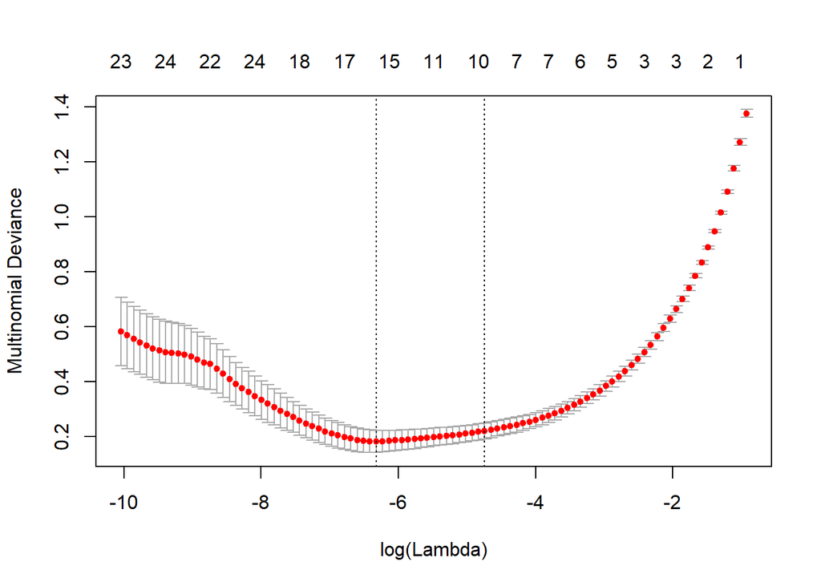

```
##            Length Class  Mode
## a0         2      -none- numeric
## beta       2      -none- list
## dfmat      2      -none- numeric
## df         1      -none- numeric
## dim        2      -none- numeric
## lambda     1      -none- numeric
## dev.ratio  1      -none- numeric
## nulldev    1      -none- numeric
## npasses    1      -none- numeric
## jerr       1      -none- numeric
## offset     1      -none- logical
## classnames 2      -none- character
## grouped    1      -none- logical
## call       6      -none- call
## nobs       1      -none- numeric
```

```
## [1] "confusion matrix for the train data"
```

```
##
##       B   M
##   B 203   5
##   M   2 159
```

```
## [1] "train error"       "0.018970189701897"
```

```
## [1] "confusion matrix for the test data"
```

```
##
##       B   M
##   B 146   0
##   M   6  48
```

```
## [1] "test error" "0.03"
```

As can be seen from the results, the cross validation error on the test data is lower than the test error since the cross validation tries to explain the train data well ( by dividing the train data into folds ). However, it can be said that the error rates are consistent with each other and the model performs well on this data set. The performance metric is confusion matrix and the error rates were calculated based on the confusion matrix created by using the model with these parameters.

## 2.2. - Decision Tree

For the decision tree algorithm, the values (2,3,4) for the minimal number of observations per tree leaf and the values (0.005, 0.01, 0.015) for the complexity parameter were used respectively. All the calculations were made based on this sequence (there is a for loop for the respective values). The decision trees, train and the test errors can be seen below for the respective parameter value sequence. Also the visual representation of the cross-validation result is given at the end of the calculations.

```
##
## Classification tree:
## rpart(formula = V2 ~ ., data = Dataset_1_train, control = rpart.control(minbucket = 1 +
##     i, cp = 0.005 * i))
##
## Variables actually used in tree construction:
## [1] V25 V27 V29 V3  V4  V7  V8
##
## Root node error: 164/369 = 0.44444
##
## n= 369
##
##          CP nsplit rel error  xerror     xstd
## 1 0.8353659      0  1.000000 1.00000 0.058203
## 2 0.0365854      1  0.164634 0.17683 0.031520
## 3 0.0243902      2  0.128049 0.17683 0.031520
## 4 0.0121951      4  0.079268 0.17073 0.031017
## 5 0.0060976      6  0.054878 0.15854 0.029976
## 6 0.0050000      8  0.042683 0.15854 0.029976
```

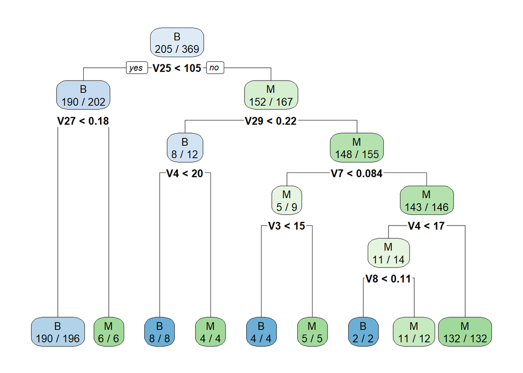

```
##
##       B   M
##   B 204   6
##   M   1 158
## [1] "trainerror"        "0.018970189701897"
## [1] "test error"         "0.0800000000000001"
##
## Classification tree:
## rpart(formula = V2 ~ ., data = Dataset_1_train, control = rpart.control(minbucket = 1 +
##     i, cp = 0.005 * i))
##
## Variables actually used in tree construction:
## [1] V25 V27 V29 V3  V4  V7
##
## Root node error: 164/369 = 0.44444
##
## n= 369
##
##         CP nsplit rel error  xerror     xstd
## 1 0.835366      0  1.000000 1.00000 0.058203
## 2 0.036585      1  0.164634 0.20122 0.033425
## 3 0.024390      2  0.128049 0.16463 0.030503
## 4 0.012195      4  0.079268 0.15854 0.029976
## 5 0.010000      6  0.054878 0.15854 0.029976
```

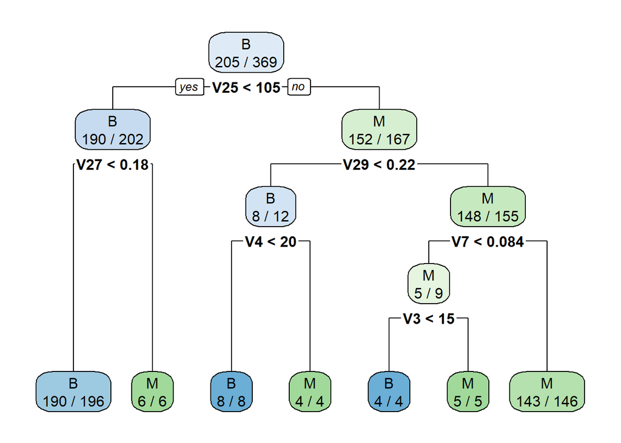

```
##
##       B   M
##   B 202   6
##   M   3 158
## [1] "trainerror"        "0.024390243902439"
## [1] "test error" "0.09"
##
## Classification tree:
## rpart(formula = V2 ~ ., data = Dataset_1_train, control = rpart.control(minbucket = 1 +
##     i, cp = 0.005 * i))
##
## Variables actually used in tree construction:
## [1] V25 V27 V29 V4
##
## Root node error: 164/369 = 0.44444
##
## n= 369
##
##         CP nsplit rel error  xerror     xstd
## 1 0.835366      0  1.000000 1.00000 0.058203
## 2 0.036585      1  0.164634 0.17683 0.031520
## 3 0.024390      2  0.128049 0.16463 0.030503
## 4 0.015000      4  0.079268 0.16463 0.030503
```

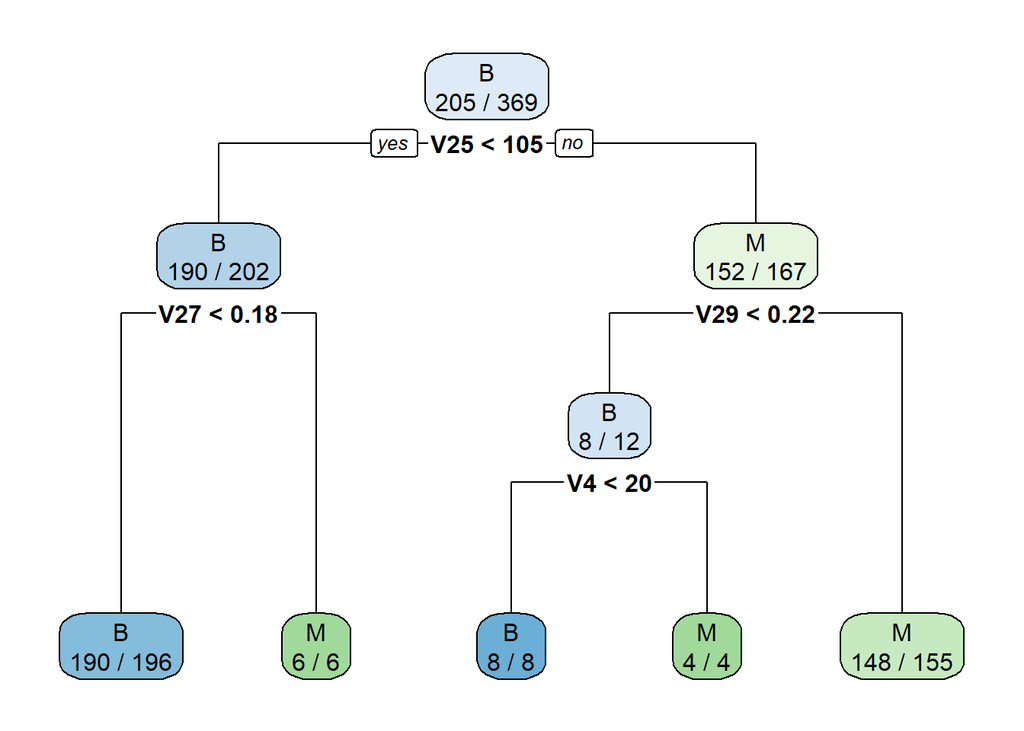

```
##
##       B   M
##   B 198   6
##   M   7 158
## [1] "trainerror"        "0.035230352303523"
## [1] "test error" "0.1"
```

```
## [1] "Visual representation of the cross-validation result"
```

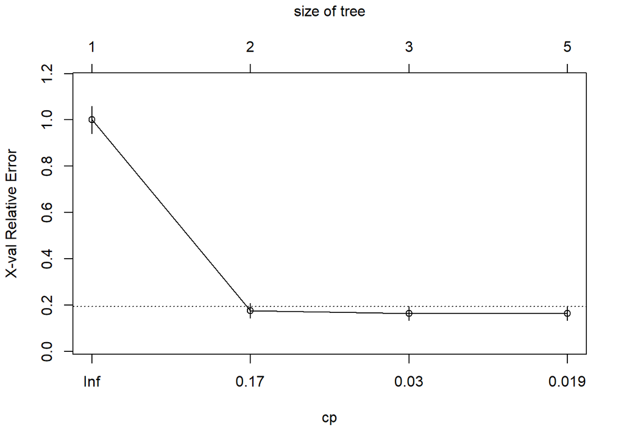

As can be seen above, the best value of the minimal number of observations per tree leaf is 2 and the best value of the complexity parameter is 0.005 for both train and the test error. The cross validation error and the test error seem to be consistent here. The performance metric is confusion matrix and the error rates were calculated based on the confusion matrix created by using the model with these parameters.

## 2.3. - Support Vector Machine

The support vector machine technique was implemented for both polynomial and the Gaussian kernel type seperately.

### 2.3.a - Support Vector Machine for Polynomial Kernel

In this part, the procedure with polynomial kernel was first implemented on the train data and cross validation was used so that the optimum parameter values can be obtained. Then the model was created with the best parameter values and used on the test data. After all, the results, confusion matrix and the test error can be obtained below. All the procedures can be followed below sequentially.

```
##
## Call:
## svm(formula = V2 ~ ., data = Dataset_1_train, kernel = "polynomial",
##     cost = 0.1)
##
##
## Parameters:
##    SVM-Type:  C-classification
##  SVM-Kernel:  polynomial
##        cost:  0.1
##      degree:  3
##       gamma:  0.03333333
##      coef.0:  0
##
## Number of Support Vectors:  227
```

```
##
## Parameter tuning of 'svm':
##
## - sampling method: 10-fold cross validation
##
## - best parameters:
##  cost
##    10
##
## - best performance: 0.04887387
##
## - Detailed performance results:
##    cost      error dispersion
## 1 1e-03 0.43348348 0.05878719
## 2 1e-02 0.36846847 0.08614485
## 3 1e-01 0.20330330 0.04298597
## 4 1e+00 0.09767267 0.05000304
## 5 1e+01 0.04887387 0.03581718
## 6 1e+02 0.05435435 0.03179498
```

```
##
## Call:
## svm(formula = V2 ~ ., data = Dataset_1_train, kernel = "polynomial",
##     cost = as.numeric(bestcost[1, 1]))
##
##
## Parameters:
##    SVM-Type:  C-classification
##  SVM-Kernel:  polynomial
##        cost:  10
##      degree:  3
##       gamma:  0.03333333
##      coef.0:  0
##
## Number of Support Vectors:  93
```

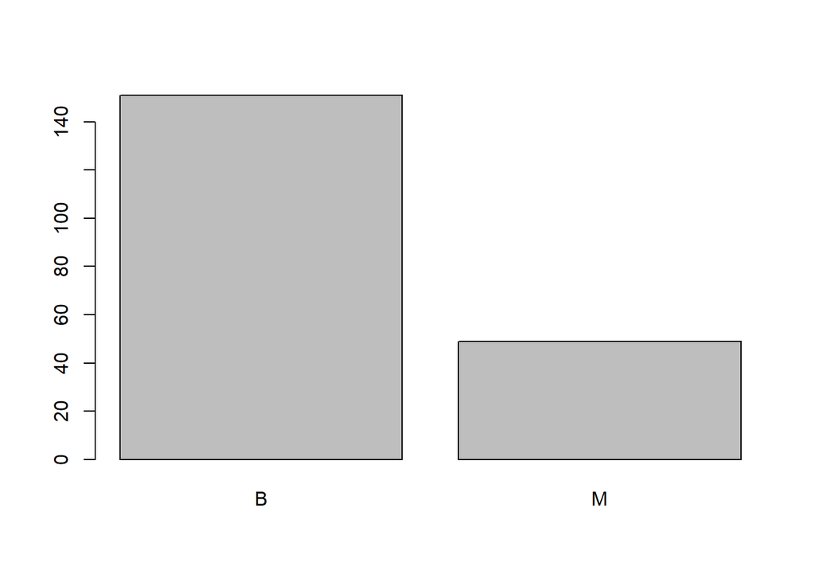

```
##
## p     B   M
##   B 151   0
##   M   1  48
```

```
## [1] "test error" "0.005"
```

### 2.3.b - Support Vector Machine for Gaussian Kernel

In this part, again, the procedure was first implemented on the train data so that the optimum parameter values can be obtained. Then the model was created and used on the test data. After all, the results, confusion matrix and the test error can be obtained below.

```
##
## Call:
## svm(formula = V2 ~ ., data = Dataset_1_train, kernel = "radial",
##     cost = 0.1)
##
##
## Parameters:
##    SVM-Type:  C-classification
##  SVM-Kernel:  radial
##        cost:  0.1
##       gamma:  0.03333333
##
## Number of Support Vectors:  178
```

```
##
## Parameter tuning of 'svm':
##
## - sampling method: 10-fold cross validation
##
## - best parameters:
##  cost
##     1
##
## - best performance: 0.03543544
##
## - Detailed performance results:
##    cost      error dispersion
## 1 1e-03 0.44429429 0.05149296
## 2 1e-02 0.44429429 0.05149296
## 3 1e-01 0.06539039 0.05113985
## 4 1e+00 0.03543544 0.03682813
## 5 1e+01 0.04902402 0.04638218
## 6 1e+02 0.05983483 0.04628486
```

```
##
## Call:
## svm(formula = V2 ~ ., data = Dataset_1_train, kernel = "radial",
##     cost = as.numeric(bestcost[1, 1]))
##
##
## Parameters:
##    SVM-Type:  C-classification
##  SVM-Kernel:  radial
##        cost:  1
##       gamma:  0.03333333
##
## Number of Support Vectors:  97
```

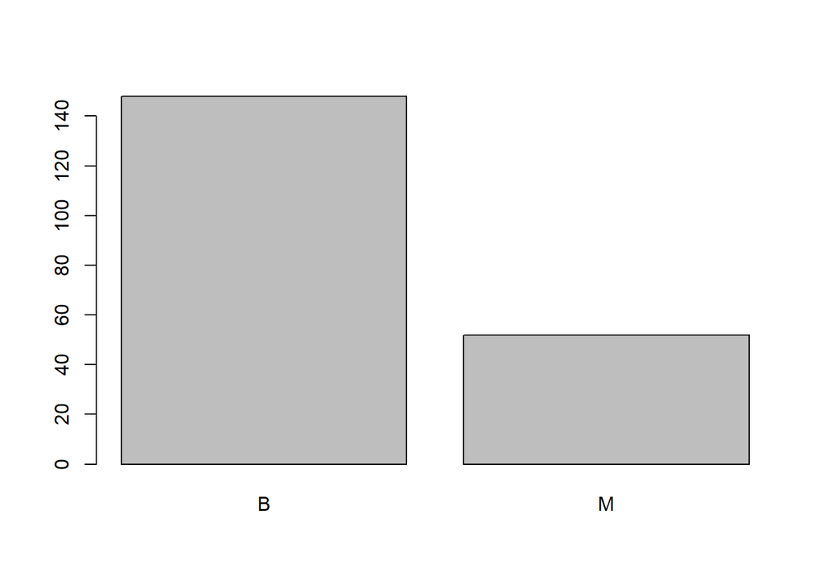

```
##
## p     B   M
##   B 148   0
##   M   4  48
```

```
## [1] "test error" "0.02"
```

In this part, the polynomial kernel was the better one (test error = 0.005) compared to the Gaussian kernel type (test error=0.02). The performance metric is confusion matrix and the error rates were calculated based on the confusion matrix created by using the model with these parameters. It can be said that the error rates are consistent and there is no risk of ovevrfitting/underfitting.

## 2.4. - Random Forest

```
##
## Call:
##  randomForest(formula = V2 ~ ., data = Dataset_1_train, proximity = TRUE,      mtry = 10 + 2 * i)
##                Type of random forest: classification
##                      Number of trees: 500
## No. of variables tried at each split: 12
##
##         OOB estimate of  error rate: 5.42%
## Confusion matrix:
##     B   M class.error
## B 194  11  0.05365854
## M   9 155  0.05487805
##
## Call:
##  randomForest(formula = V2 ~ ., data = Dataset_1_train, proximity = TRUE,      mtry = 10 + 2 * i)
##                Type of random forest: classification
##                      Number of trees: 500
## No. of variables tried at each split: 14
##
##         OOB estimate of  error rate: 4.61%
## Confusion matrix:
##     B   M class.error
## B 196   9  0.04390244
## M   8 156  0.04878049
##
## Call:
##  randomForest(formula = V2 ~ ., data = Dataset_1_train, proximity = TRUE,      mtry = 10 + 2 * i)
##                Type of random forest: classification
##                      Number of trees: 500
## No. of variables tried at each split: 16
##
##         OOB estimate of  error rate: 5.69%
## Confusion matrix:
##     B   M class.error
## B 192  13  0.06341463
## M   8 156  0.04878049
##
## Call:
##  randomForest(formula = V2 ~ ., data = Dataset_1_train, proximity = TRUE,      mtry = 10 + 2 * i)
##                Type of random forest: classification
##                      Number of trees: 500
## No. of variables tried at each split: 18
##
##         OOB estimate of  error rate: 4.88%
## Confusion matrix:
##     B   M class.error
## B 195  10  0.04878049
## M   8 156  0.04878049
##
## Call:
##  randomForest(formula = V2 ~ ., data = Dataset_1_train, proximity = TRUE,      mtry = 10 + 2 * i)
##                Type of random forest: classification
##                      Number of trees: 500
## No. of variables tried at each split: 20
##
##         OOB estimate of  error rate: 4.88%
## Confusion matrix:
##     B   M class.error
## B 194  11  0.05365854
## M   7 157  0.04268293
```

```
##
## Call:
##  randomForest(formula = V2 ~ ., data = Dataset_1_train, proximity = TRUE,      mtry = 20)
##                Type of random forest: classification
##                      Number of trees: 500
## No. of variables tried at each split: 20
##
##         OOB estimate of  error rate: 4.88%
## Confusion matrix:
##     B   M class.error
## B 194  11  0.05365854
## M   7 157  0.04268293
```

```
## [1] "train error"        "0.0490287749579561"
```

```
##
## p     B   M
##   B 144   2
##   M   8  46
```

```
## [1] "test error" "0.05"
```

After completing the implementation, train error was found as 0.049 while the test error was found as 0.05. The performance metric is confusion matrix and the error rates were calculated based on the confusion matrix created by using the model with these parameters. Also, it can be said that the error rates are consistent. There is not a problem with this model about overfitting/underfitting.

## 2.5. - Stochastic Gradient Boosting (SGB):

In this part, different values of depth, learning rate and the number of trees were tried. After all, the best values of these parameters were obtained from the cross validation. Note that, after the implementation of the procedure, the model gives the result in the probability format. After converting these probability data to the categorical results, the confusion matrices were created and the error rates were calculated these matrices. Finally, the results, train and the test error were obtained as can be seen below.

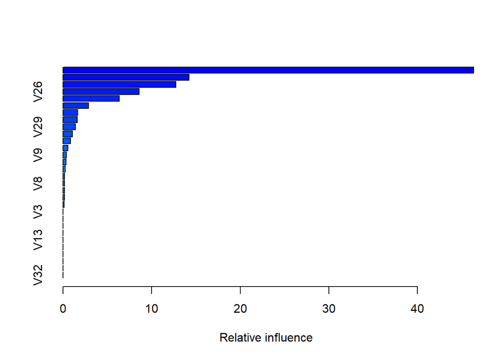

```
##     var    rel.inf
## V25 V25 46.3364868
## V30 V30 14.2104756
## V10 V10 12.7542603
## V26 V26  8.6113577
## V23 V23  6.3442376
## V4   V4  2.8630932
## V27 V27  1.6570194
## V6   V6  1.6215169
## V29 V29  1.3855720
## V24 V24  1.0563897
## V16 V16  0.8318744
## V31 V31  0.5341773
## V9   V9  0.3795567
## V18 V18  0.3477182
## V14 V14  0.2490477
## V11 V11  0.1860431
## V8   V8  0.1762672
## V19 V19  0.1688885
## V15 V15  0.1651337
## V21 V21  0.1208838
## V3   V3  0.0000000
## V5   V5  0.0000000
## V7   V7  0.0000000
## V12 V12  0.0000000
## V13 V13  0.0000000
## V17 V17  0.0000000
## V20 V20  0.0000000
## V22 V22  0.0000000
## V28 V28  0.0000000
## V32 V32  0.0000000
```

```
## [1] "Confusion Matrix for train data"
```

```
##
##       B   M
##   B 205   0
##   M   0 164
```

```
## [1] "train error" "0"
```

[output not shown]

[output cut: 188 more lines]

```
## [1] "Confusion Matrix for test data"
```

```
##
##       B   M
##   B 149   0
##   M   3  48
```

```
## [1] "test error" "0.015"
```

As can be seen from above, the train error is zero means that there is a risk of overfitting. The test error was obtained as 0.015. Also note that, the number of trees = 100 is sufficient for this particular dataset. As the number of trees increase, the error rate is inclined to decrease. Remember that the performance metric here is the confusion matrix and the error rates were calculated according to these matrices.

# 3. Analyzes for Dataset 2

## 3.1. - Penalized Regression Approach

In this part, penalized regression was used to predict the response of this data set (there are 8 different classes to predict). First of all, cross validation procedure was carried out on the train data set and this worked properly. The details and the lambda values for different deviances can be seen below.

```
## $lambda
##  [1] 1.472448e-01 1.341640e-01 1.222452e-01 1.113853e-01 1.014901e-01
##  [6] 9.247401e-02 8.425888e-02 7.677355e-02 6.995320e-02 6.373875e-02
## [11] 5.807638e-02 5.291703e-02 4.821603e-02 4.393265e-02 4.002979e-02
## [16] 3.647366e-02 3.323344e-02 3.028107e-02 2.759098e-02 2.513988e-02
## [21] 2.290652e-02 2.087157e-02 1.901739e-02 1.732794e-02 1.578858e-02
## [26] 1.438596e-02 1.310795e-02 1.194348e-02 1.088245e-02 9.915685e-03
## [31] 9.034803e-03 8.232176e-03 7.500852e-03 6.834497e-03 6.227339e-03
## [36] 5.674120e-03 5.170047e-03 4.710754e-03 4.292264e-03 3.910951e-03
## [41] 3.563513e-03 3.246940e-03 2.958491e-03 2.695667e-03 2.456191e-03
## [46] 2.237990e-03 2.039173e-03 1.858018e-03 1.692957e-03 1.542560e-03
## [51] 1.405523e-03 1.280660e-03 1.166890e-03 1.063226e-03 9.687723e-04
## [56] 8.827093e-04 8.042918e-04 7.328408e-04 6.677372e-04 6.084173e-04
## [61] 5.543672e-04 5.051187e-04 4.602454e-04 4.193584e-04 3.821038e-04
## [66] 3.481587e-04 3.172293e-04 2.890475e-04 2.633693e-04 2.399723e-04
```

[output cut: 194 more lines]

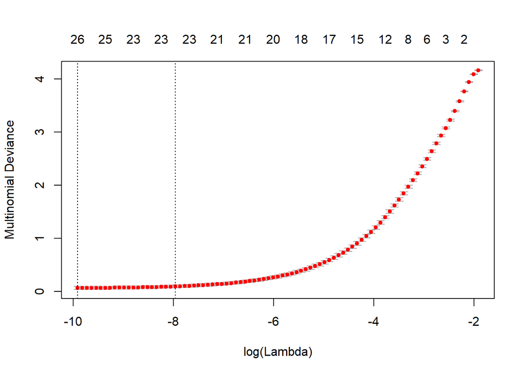

In the next step, the optimum lambda value obtained from cross validation was used on the model. However, the model gave an error ( maybe the problem occured because of the RStudio, or it occured because the data set consists of more than two“classes”). The code given below was tried to implement;

```
# fit model
fit <- glmnet(new_train,as.matrix(Dataset_2_train$class) ,family="multinomial", alpha=1,
              lambda=cross_validation$lambda.min)
# summarize the fit
summary(fit)
# make predictions for train data
predictions <- predict(fit, new_train, type="class")
# summarize accuracy for train data
tab<-table(predictions[,1],Dataset_2_train$class)
print("confusion matrix for the train data")
print(tab)
train_error<-1-sum(diag(tab)/sum(tab))
print(c("train error",train_error))

# make predictions for test data
predictions <- predict(fit, new_test, type="class")
# summarize accuracy for train data
tab<-table(predictions[,1],Dataset_2_test$class)
print("confusion matrix for the test data")
print(tab)
test_error<-1-sum(diag(tab)/sum(tab))
print(c("test error",test_error))
```

And the following error showed up;

“Error in matrix(fit$a0[seq(lmu * nc)], nc, lmu, dimnames = list(classnames, : length of ‘dimnames’ [2] not equal to array extent In addition: Warning message: from glmnet Fortran code (error code -1); Convergence for 1th lambda value not reached after maxit=100000 iterations; solutions for larger lambdas returned”

Therefore, penalized regression approach could not be implemented on this particular data set.

## 3.2. - Decision Tree

In this part, the values (2,3,4) for the minimal number of observations per tree leaf and the values (0.005, 0.01, 0.015) for the complexity parameter were used respectively. All the calculations were made based on this sequence (there is a for loop for the respective values). The decision trees, train and the test errors can be seen below for the respective parameter value sequence. Also, the visual representation of the cross-validation result is given at the end of the calculations.

```
##
## Classification tree:
## rpart(formula = class ~ ., data = Dataset_2_train, control = rpart.control(minbucket = 1 +
##     i, cp = 0.005 * i))
##
## Variables actually used in tree construction:
##  [1] APP_N           BAD_N           Bcatenin_N      BDNF_N
##  [5] BRAF_N          CDK5_N          CREB_N          DYRK1A_N
##  [9] ERBB4_N         GluR4_N         IL1B_N          P38_N
## [13] pCAMKII_N       pCFOS_N         pGSK3B_Tyr216_N PKCA_N
## [17] pP70S6_N        pPKCAB_N        pPKCG_N         PSD95_N
## [21] RAPTOR_N        SHH_N           SNCA_N          SOD1_N
## [25] Tau_N
##
## Root node error: 698/810 = 0.86173
##
## n= 810
##
##           CP nsplit rel error  xerror     xstd
## 1  0.1532951      0  1.000000 1.01003 0.013696
## 2  0.1189112      1  0.846705 0.86676 0.017728
## 3  0.0981375      2  0.727794 0.74928 0.019503
## 4  0.0659026      4  0.531519 0.55158 0.020362
## 5  0.0587393      5  0.465616 0.51576 0.020261
## 6  0.0186246      7  0.348138 0.41691 0.019563
## 7  0.0171920      8  0.329513 0.39685 0.019342
## 8  0.0157593     10  0.295129 0.38539 0.019203
## 9  0.0143266     14  0.232092 0.35244 0.018750
## 10 0.0128940     16  0.203438 0.31232 0.018084
## 11 0.0100287     18  0.177650 0.29083 0.017670
## 12 0.0085960     20  0.157593 0.27507 0.017340
## 13 0.0071633     23  0.131805 0.25215 0.016815
## 14 0.0057307     26  0.110315 0.24928 0.016746
## 15 0.0050000     32  0.071633 0.22779 0.016195
```

[figure not shown]

```
##
##          c-CS-m c-CS-s c-SC-m c-SC-s t-CS-m t-CS-s t-SC-m t-SC-s
##   c-CS-m    103      3      2      0      0      1      0      0
##   c-CS-s      2     94      0      0      1      2      0      0
##   c-SC-m      0      1     97      0      0      0      2      0
##   c-SC-s      0      0      5     93      0      0      3      0
##   t-CS-m      6      2      0      0    101      2      0      1
##   t-CS-s      0      2      0      0      2     73      0      0
##   t-SC-m      1      1      6      3      0      0    100      1
##   t-SC-s      0      1      0      0      0      0      0     99
## [1] "trainerror"         "0.0617283950617284"
## [1] "test error"        "0.151851851851852"
##
## Classification tree:
## rpart(formula = class ~ ., data = Dataset_2_train, control = rpart.control(minbucket = 1 +
##     i, cp = 0.005 * i))
##
## Variables actually used in tree construction:
##  [1] APP_N      BAD_N      Bcatenin_N BRAF_N     DYRK1A_N   ERBB4_N
##  [7] IL1B_N     P38_N      pCAMKII_N  PKCA_N     pP70S6_N   pPKCAB_N
## [13] pPKCG_N    RAPTOR_N   SHH_N      SNCA_N     SOD1_N     Tau_N
##
## Root node error: 698/810 = 0.86173
##
## n= 810
##
##          CP nsplit rel error  xerror     xstd
## 1  0.153295      0   1.00000 1.01289 0.013584
## 2  0.118911      1   0.84670 0.87249 0.017612
## 3  0.098138      2   0.72779 0.75501 0.019440
## 4  0.065903      4   0.53152 0.52436 0.020292
## 5  0.058739      5   0.46562 0.50716 0.020225
## 6  0.018625      7   0.34814 0.41547 0.019548
## 7  0.017192      8   0.32951 0.38109 0.019149
## 8  0.015759     10   0.29513 0.36390 0.018917
## 9  0.014327     14   0.23209 0.35100 0.018729
## 10 0.012894     16   0.20344 0.33524 0.018481
## 11 0.010029     18   0.17765 0.30659 0.017978
## 12 0.010000     20   0.15759 0.28940 0.017641
```

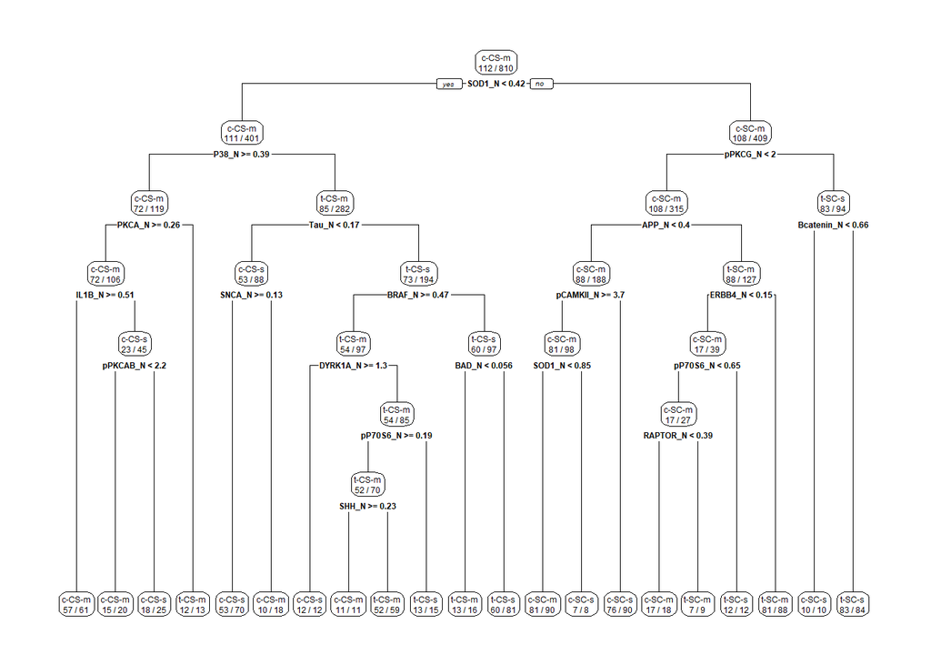

```
##
##          c-CS-m c-CS-s c-SC-m c-SC-s t-CS-m t-CS-s t-SC-m t-SC-s
##   c-CS-m     93      6      2      0      6      3      0      0
##   c-CS-s      3     83      0      0     19      2      0      0
##   c-SC-m      0      1     98      0      0      0      9      0
##   c-SC-s      0      0      7     93      0      0      8      0
##   t-CS-m      8      2      0      0     77      0      0      1
##   t-CS-s      7     10      0      0      2     73      0      4
##   t-SC-m      1      1      3      3      0      0     88      1
##   t-SC-s      0      1      0      0      0      0      0     95
## [1] "trainerror"        "0.135802469135803"
## [1] "test error"        "0.203703703703704"
##
## Classification tree:
## rpart(formula = class ~ ., data = Dataset_2_train, control = rpart.control(minbucket = 1 +
##     i, cp = 0.005 * i))
##
## Variables actually used in tree construction:
##  [1] APP_N     BAD_N     BRAF_N    DYRK1A_N  ERBB4_N   P38_N     pCAMKII_N
##  [8] PKCA_N    pP70S6_N  pPKCG_N   SHH_N     SOD1_N    Tau_N
##
## Root node error: 698/810 = 0.86173
##
## n= 810
##
##         CP nsplit rel error  xerror     xstd
## 1 0.153295      0   1.00000 1.02865 0.012938
## 2 0.118911      1   0.84670 0.88252 0.017402
## 3 0.098138      2   0.72779 0.76504 0.019325
## 4 0.065903      4   0.53152 0.54298 0.020345
## 5 0.058739      5   0.46562 0.48281 0.020098
## 6 0.018625      7   0.34814 0.42693 0.019663
## 7 0.017192      8   0.32951 0.39542 0.019325
## 8 0.015759     10   0.29513 0.38395 0.019185
## 9 0.015000     14   0.23209 0.35960 0.018856
```

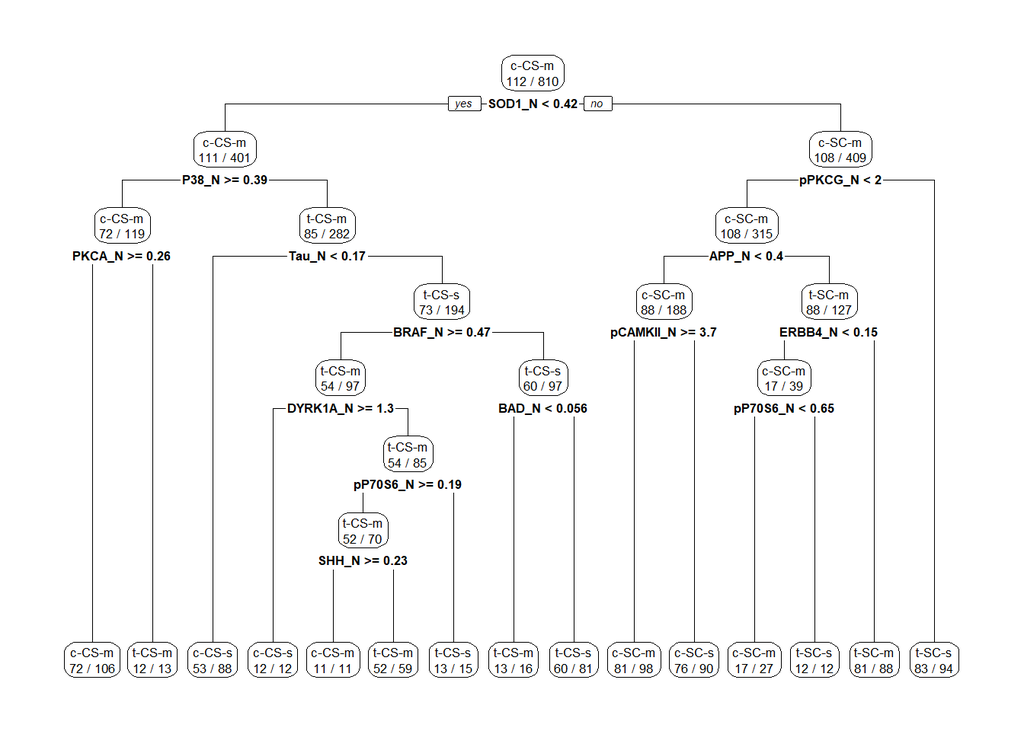

```
##
##          c-CS-m c-CS-s c-SC-m c-SC-s t-CS-m t-CS-s t-SC-m t-SC-s
##   c-CS-m     83     24      2      0      7      1      0      0
##   c-CS-s     13     65      0      0     18      4      0      0
##   c-SC-m      1      2     98      7      0      0     17      0
##   c-SC-s      0      0      7     76      0      0      7      0
##   t-CS-m      8      2      0      0     77      0      0      1
##   t-CS-s      7     10      0      0      2     73      0      4
##   t-SC-m      0      0      3      3      0      0     81      1
##   t-SC-s      0      1      0     10      0      0      0     95
## [1] "trainerror" "0.2"
## [1] "test error"        "0.259259259259259"
```

```
## [1] "Visual representation of the cross-validation result"
```

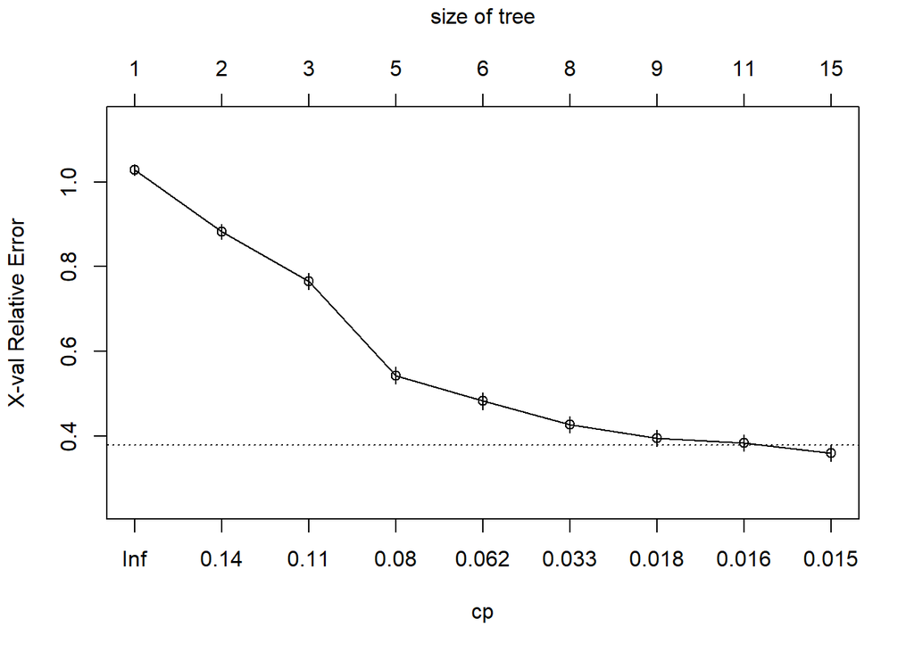

As can be seen above, the decision tree algorithm performs better with the minimal number of observation per tree leaf 2 and the complexity parameter 0.005 (these values are based on our trials. As it can be seen from the above graph, there are better cp values for this model). With these values, both train and the test error are at the minimum level for the given parameter values.The cross validation error and the test error seem to be consistent here. The performance metric is confusion matrix and the error rates were calculated based on the confusion matrix created by using the model with these parameters.

## 3.3. - Support Vector Machines

The support vector machine technique was implemented for both polynomial and the Gaussian kernel type seperately.

### 3.3.a. - Support Vector Machines for Polynomial Kernel

In this part, the procedure with polynomial kernel was first implemented on the train data and cross validation was used so that the optimum parameter values can be obtained. Then the model was created with the best parameter values and used on the test data. After all, the results, confusion matrix and the test error can be obtained below. All the procedures can be followed below sequentially.

```
##
## Call:
## svm(formula = class ~ ., data = Dataset_2_train, kernel = "polynomial",
##     cost = 0.1)
##
##
## Parameters:
##    SVM-Type:  C-classification
##  SVM-Kernel:  polynomial
##        cost:  0.1
##      degree:  3
##       gamma:  0.01298701
##      coef.0:  0
##
## Number of Support Vectors:  764
```

```
##
## Parameter tuning of 'svm':
##
## - sampling method: 10-fold cross validation
##
## - best parameters:
##  cost
##   100
##
## - best performance: 0.008641975
##
## - Detailed performance results:
##    cost       error  dispersion
## 1 1e-03 0.891358025 0.034821721
## 2 1e-02 0.875308642 0.037468904
## 3 1e-01 0.555555556 0.070561433
## 4 1e+00 0.062962963 0.022875625
## 5 1e+01 0.009876543 0.007808093
## 6 1e+02 0.008641975 0.008332698
```

```
##
## Call:
## svm(formula = class ~ ., data = Dataset_2_train, kernel = "polynomial",
##     cost = as.numeric(bestcost[1, 1]))
##
##
## Parameters:
##    SVM-Type:  C-classification
##  SVM-Kernel:  polynomial
##        cost:  100
##      degree:  3
##       gamma:  0.01298701
##      coef.0:  0
##
## Number of Support Vectors:  375
```

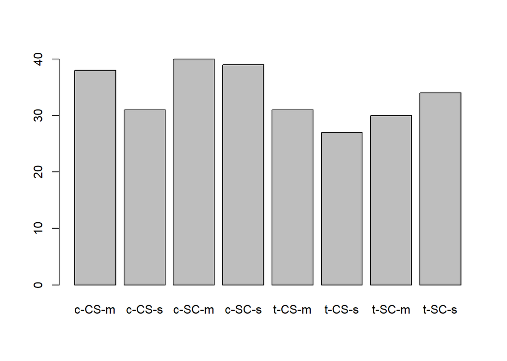

```
##
## p        c-CS-m c-CS-s c-SC-m c-SC-s t-CS-m t-CS-s t-SC-m t-SC-s
##   c-CS-m     38      0      0      0      0      0      0      0
##   c-CS-s      0     31      0      0      0      0      0      0
##   c-SC-m      0      0     40      0      0      0      0      0
##   c-SC-s      0      0      0     39      0      0      0      0
##   t-CS-m      0      0      0      0     31      0      0      0
##   t-CS-s      0      0      0      0      0     27      0      0
##   t-SC-m      0      0      0      0      0      0     30      0
##   t-SC-s      0      0      0      0      0      0      0     34
```

```
## [1] "test error" "0"
```

### 3.3.b. - Support Vector Machines for Gaussian Kernel

```
##
## Call:
## svm(formula = class ~ ., data = Dataset_2_train, kernel = "radial",
##     cost = 0.1)
##
##
## Parameters:
##    SVM-Type:  C-classification
##  SVM-Kernel:  radial
##        cost:  0.1
##       gamma:  0.01298701
##
## Number of Support Vectors:  802
```

```
##
## Parameter tuning of 'svm':
##
## - sampling method: 10-fold cross validation
##
## - best parameters:
##  cost
##     1
##
## - best performance: 0.007407407
##
## - Detailed performance results:
##    cost       error dispersion
## 1 1e-03 0.895061728 0.03599353
## 2 1e-02 0.895061728 0.03599353
## 3 1e-01 0.288888889 0.04515512
## 4 1e+00 0.007407407 0.01041079
## 5 1e+01 0.007407407 0.01041079
## 6 1e+02 0.007407407 0.01041079
```

```
##
## Call:
## svm(formula = class ~ ., data = Dataset_2_train, kernel = "radial",
##     cost = as.numeric(bestcost[1, 1]))
##
##
## Parameters:
##    SVM-Type:  C-classification
##  SVM-Kernel:  radial
##        cost:  1
##       gamma:  0.01298701
##
## Number of Support Vectors:  587
```

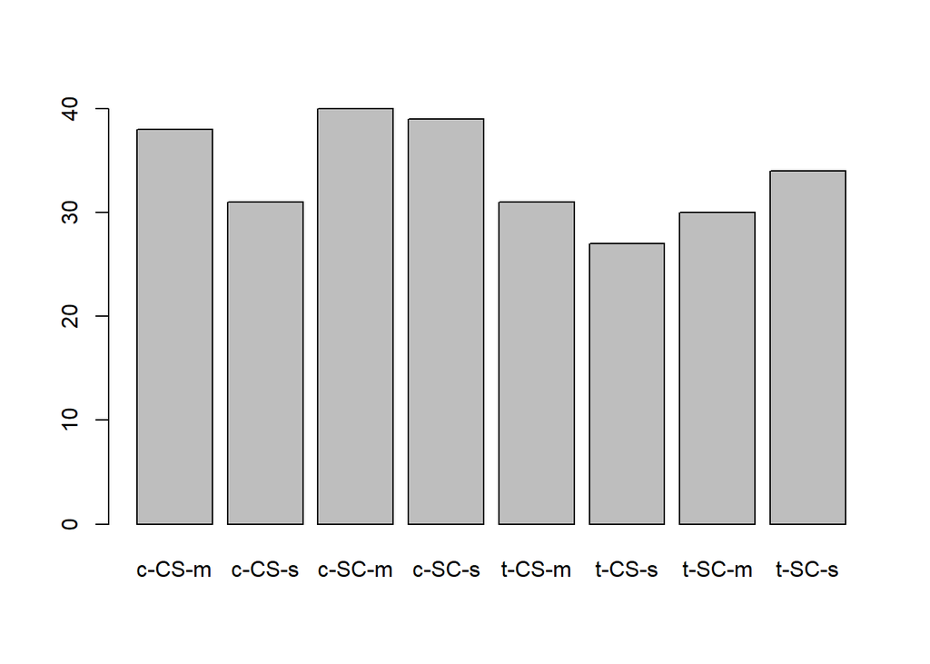

```
##
## p        c-CS-m c-CS-s c-SC-m c-SC-s t-CS-m t-CS-s t-SC-m t-SC-s
##   c-CS-m     38      0      0      0      0      0      0      0
##   c-CS-s      0     31      0      0      0      0      0      0
##   c-SC-m      0      0     40      0      0      0      0      0
##   c-SC-s      0      0      0     39      0      0      0      0
##   t-CS-m      0      0      0      0     31      0      0      0
##   t-CS-s      0      0      0      0      0     27      0      0
##   t-SC-m      0      0      0      0      0      0     30      0
##   t-SC-s      0      0      0      0      0      0      0     34
```

```
## [1] "test error" "0"
```

## 3.4. - Random Forest

In this task, the values (11,12,13,14,15) for the number of variables randomly sampled as candidates at each split (i.e. “m”) were tried in each iteration respectively. Then the best value of m was obtained from the iterations (The best value of the m was found to be 15). The results, train error, test error and the confusion matrices can be seen below.

```
##
## Call:
##  randomForest(formula = class ~ ., data = Dataset_2_train, proximity = TRUE,      mtry = 10 + i)
##                Type of random forest: classification
##                      Number of trees: 500
## No. of variables tried at each split: 11
##
##         OOB estimate of  error rate: 0.62%
## Confusion matrix:
##        c-CS-m c-CS-s c-SC-m c-SC-s t-CS-m t-CS-s t-SC-m t-SC-s class.error
## c-CS-m    112      0      0      0      0      0      0      0  0.00000000
## c-CS-s      2    102      0      0      0      0      0      0  0.01923077
## c-SC-m      0      0    108      1      0      0      1      0  0.01818182
## c-SC-s      0      0      0     96      0      0      0      0  0.00000000
## t-CS-m      0      0      0      0    104      0      0      0  0.00000000
## t-CS-s      0      0      0      0      1     77      0      0  0.01282051
## t-SC-m      0      0      0      0      0      0    105      0  0.00000000
## t-SC-s      0      0      0      0      0      0      0    101  0.00000000
## [1] "error"               "0.00623446904138869"
##
## Call:
##  randomForest(formula = class ~ ., data = Dataset_2_train, proximity = TRUE,      mtry = 10 + i)
##                Type of random forest: classification
##                      Number of trees: 500
## No. of variables tried at each split: 12
##
##         OOB estimate of  error rate: 0.62%
## Confusion matrix:
##        c-CS-m c-CS-s c-SC-m c-SC-s t-CS-m t-CS-s t-SC-m t-SC-s class.error
## c-CS-m    112      0      0      0      0      0      0      0  0.00000000
## c-CS-s      2    102      0      0      0      0      0      0  0.01923077
## c-SC-m      0      0    107      1      0      0      2      0  0.02727273
## c-SC-s      0      0      0     96      0      0      0      0  0.00000000
## t-CS-m      0      0      0      0    104      0      0      0  0.00000000
## t-CS-s      0      0      0      0      0     78      0      0  0.00000000
## t-SC-m      0      0      0      0      0      0    105      0  0.00000000
## t-SC-s      0      0      0      0      0      0      0    101  0.00000000
## [1] "error"               "0.00622989356132109"
##
## Call:
```

[output cut: 40 more lines]

```
##                      Number of trees: 500
## No. of variables tried at each split: 15
##
##         OOB estimate of  error rate: 0.62%
## Confusion matrix:
##        c-CS-m c-CS-s c-SC-m c-SC-s t-CS-m t-CS-s t-SC-m t-SC-s class.error
## c-CS-m    112      0      0      0      0      0      0      0  0.00000000
## c-CS-s      2    102      0      0      0      0      0      0  0.01923077
## c-SC-m      0      0    108      0      0      0      2      0  0.01818182
## c-SC-s      0      0      0     96      0      0      0      0  0.00000000
## t-CS-m      0      0      0      0    104      0      0      0  0.00000000
## t-CS-s      0      0      0      0      1     77      0      0  0.01282051
## t-SC-m      0      0      0      0      0      0    105      0  0.00000000
## t-SC-s      0      0      0      0      0      0      0    101  0.00000000
## [1] "error"               "0.00623446904138869"
```

```
##
## Call:
##  randomForest(formula = class ~ ., data = Dataset_2_train, proximity = TRUE,      mtry = 15)
##                Type of random forest: classification
##                      Number of trees: 500
## No. of variables tried at each split: 15
##
##         OOB estimate of  error rate: 0.62%
## Confusion matrix:
##        c-CS-m c-CS-s c-SC-m c-SC-s t-CS-m t-CS-s t-SC-m t-SC-s class.error
## c-CS-m    112      0      0      0      0      0      0      0  0.00000000
## c-CS-s      2    102      0      0      0      0      0      0  0.01923077
## c-SC-m      0      0    108      0      0      0      2      0  0.01818182
## c-SC-s      0      0      0     96      0      0      0      0  0.00000000
## t-CS-m      0      0      0      0    104      0      0      0  0.00000000
## t-CS-s      0      0      0      0      1     77      0      0  0.01282051
## t-SC-m      0      0      0      0      0      0    105      0  0.00000000
## t-SC-s      0      0      0      0      0      0      0    101  0.00000000
```

```
## [1] "train error"         "0.00623446904138869"
```

```
##
## p        c-CS-m c-CS-s c-SC-m c-SC-s t-CS-m t-CS-s t-SC-m t-SC-s
##   c-CS-m     38      2      0      0      0      0      0      0
##   c-CS-s      0     29      0      0      0      0      0      0
##   c-SC-m      0      0     40      0      0      0      0      0
##   c-SC-s      0      0      0     39      0      0      0      0
##   t-CS-m      0      0      0      0     31      0      0      0
##   t-CS-s      0      0      0      0      0     27      0      0
##   t-SC-m      0      0      0      0      0      0     30      0
##   t-SC-s      0      0      0      0      0      0      0     34
```

```
## [1] "test error"          "0.00740740740740742"
```

After completing the implementation, train error was found as 0.0062 while the test error was found as 0.0074, which means tht this algorithm also performs well on this dataset. The performance metric is confusion matrix and the error rates were calculated based on the confusion matrix created by using the model with these parameters. Also, it can be said that the error rates are consistent. There is not a problem with this model about overfitting/underfitting.

## 3.5. - Stochastic Gradient Boosting (SGB)

In this part, different values of depth, learning rate and the number of trees were tried. After all, the best values of these parameters were obtained from the cross validation. Note that, after the implementation of the procedure, the model gives the result in the probability format. After converting these probability data to the categorical results, the confusion matrices were created and the error rates were calculated these matrices. Finally, the results, train and the test error were obtained as can be seen below. Finally, the results, confusion matrices, train and the test error were obtained as can be seen below.

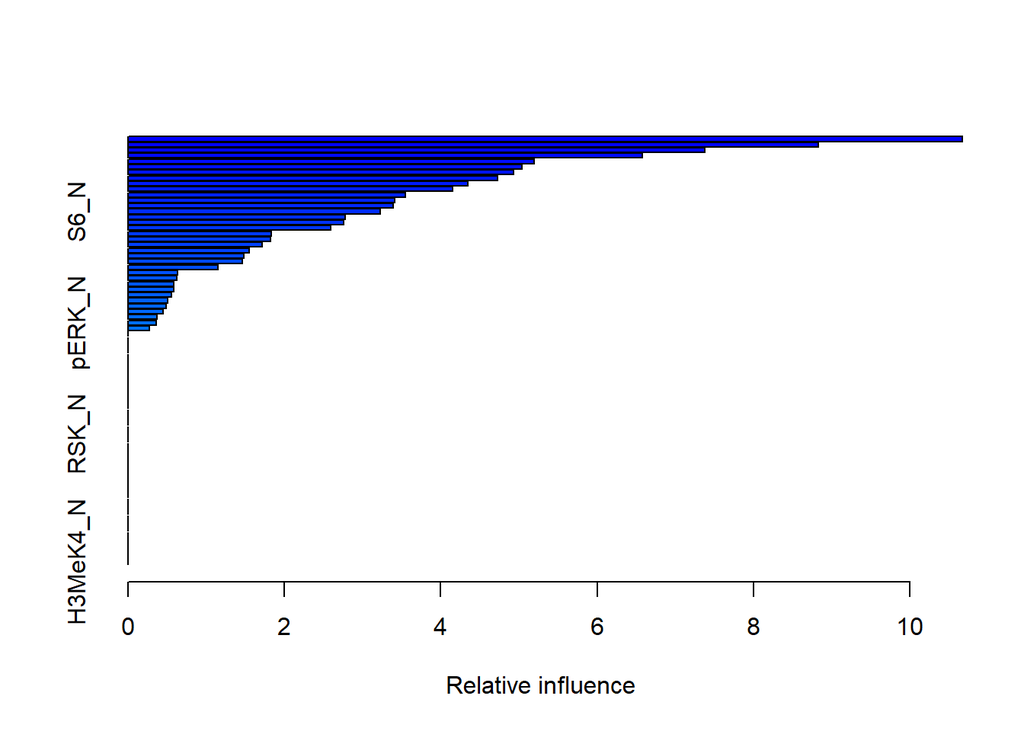

```
##                             var    rel.inf
## SOD1_N                   SOD1_N 10.6668166
## pNUMB_N                 pNUMB_N  8.8314694
## Ubiquitin_N         Ubiquitin_N  7.3740777
## pPKCG_N                 pPKCG_N  6.5739923
## pPKCAB_N               pPKCAB_N  5.1969183
## P38_N                     P38_N  5.0357658
## CaNA_N                   CaNA_N  4.9271929
## BRAF_N                   BRAF_N  4.7289780
## ARC_N                     ARC_N  4.3420236
## pMTOR_N                 pMTOR_N  4.1549337
## pP70S6_N               pP70S6_N  3.5428330
## Tau_N                     Tau_N  3.4138385
## pGSK3B_N               pGSK3B_N  3.3926617
## S6_N                       S6_N  3.2266798
## ITSN1_N                 ITSN1_N  2.7738055
## DYRK1A_N               DYRK1A_N  2.7605717
## SNCA_N                   SNCA_N  2.5964305
## nNOS_N                   nNOS_N  1.8286173
## pCAMKII_N             pCAMKII_N  1.8267805
## GluR3_N                 GluR3_N  1.7167422
## pNR2A_N                 pNR2A_N  1.5489830
## GSK3B_N                 GSK3B_N  1.4779860
## Bcatenin_N           Bcatenin_N  1.4662278
## MTOR_N                   MTOR_N  1.1480388
## GFAP_N                   GFAP_N  0.6356504
## pNR2B_N                 pNR2B_N  0.6264697
## AcetylH3K9_N       AcetylH3K9_N  0.5899068
## NUMB_N                   NUMB_N  0.5890230
## pELK_N                   pELK_N  0.5572661
## H3AcK18_N             H3AcK18_N  0.5097547
## pAKT_N                   pAKT_N  0.4910869
## IL1B_N                   IL1B_N  0.4465111
## BAX_N                     BAX_N  0.3682752
## pERK_N                   pERK_N  0.3581141
## ADARB1_N               ADARB1_N  0.2755772
## BDNF_N                   BDNF_N  0.0000000
## NR1_N                     NR1_N  0.0000000
## NR2A_N                   NR2A_N  0.0000000
## pBRAF_N                 pBRAF_N  0.0000000
```

[output cut: 23 more lines]

```
## RRP1_N                   RRP1_N  0.0000000
## ERBB4_N                 ERBB4_N  0.0000000
## GluR4_N                 GluR4_N  0.0000000
## P3525_N                 P3525_N  0.0000000
## pCASP9_N               pCASP9_N  0.0000000
## PSD95_N                 PSD95_N  0.0000000
## pGSK3B_Tyr216_N pGSK3B_Tyr216_N  0.0000000
## SHH_N                     SHH_N  0.0000000
## BAD_N                     BAD_N  0.0000000
## BCL2_N                   BCL2_N  0.0000000
## pS6_N                     pS6_N  0.0000000
## pCFOS_N                 pCFOS_N  0.0000000
## SYP_N                     SYP_N  0.0000000
## EGR1_N                   EGR1_N  0.0000000
## H3MeK4_N               H3MeK4_N  0.0000000
```

```
## [1] "confusion matrix for train data"
```

```
##
##              c-CS-m c-CS-s c-SC-m c-SC-s t-CS-m t-CS-s t-SC-m t-SC-s
##   c-CS-m.100    112      0      0      0      0      0      0      0
##   c-CS-s.100      0    101      0      0      1      0      0      0
##   c-SC-m.100      0      0    110      0      0      0      0      0
##   c-SC-s.100      0      0      0     95      0      0      0      0
##   t-CS-m.100      0      2      0      0    103      0      0      0
##   t-CS-s.100      0      1      0      0      0     78      0      0
##   t-SC-m.100      0      0      0      1      0      0    105      0
##   t-SC-s.100      0      0      0      0      0      0      0    101
```

```
## [1] "train error"         "0.00617283950617287"
```

```
## [1] "confusion matrix for the test data"
```

```
##
##              c-CS-m c-CS-s c-SC-m c-SC-s t-CS-m t-CS-s t-SC-m t-SC-s
##   c-CS-m.100     35      1      0      0      0      0      0      0
##   c-CS-s.100      2     28      0      0      2      0      0      0
##   c-SC-m.100      0      0     38      0      0      0      0      0
##   c-SC-s.100      0      0      1     38      0      0      1      0
##   t-CS-m.100      1      2      0      0     27      2      0      0
##   t-CS-s.100      0      0      0      0      2     25      0      0
##   t-SC-m.100      0      0      1      1      0      0     29      0
##   t-SC-s.100      0      0      0      0      0      0      0     34
```

```
## [1] "test error"         "0.0592592592592592"
```

As can be seen from the results, train and the test error rates were quitely low. It can be also seen that the model explain the train data better since the cross validation was implemented on the train data and the model created by these analyzes was used on the test data. Therefore, the test error rate is larger than the train error rate. However, it can be said that the error rates are consistent with each other. Remember that the performance metric here is the confusion matrix and the error rates were calculated according to these matrices.

# 4. Analyzes for Dataset 3

## 4.1. - Penalized Regression Approach

As described before, this is a regression dataset and the aim is to predict the critical temperature value (a continuous, numerical value). In this part, cross validation was implemented on the train data set and the best value of the lambda was found after 10 fold cross validation. Then this value was used on the model and this model was used for predicting the critical temperature. Since the response variable is numeric, family was selected as “Gaussian”. All the procedures, results, error rates for the performance of the model on train and the test data can be seen below. Since this is a regression problem, the performance metric is coefficient of determination.

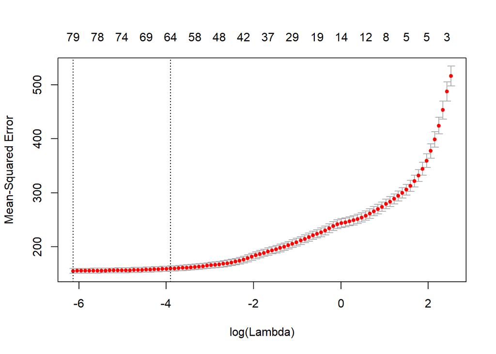

```
##           Length Class     Mode
## a0         1     -none-    numeric
## beta      81     dgCMatrix S4
## df         1     -none-    numeric
## dim        2     -none-    numeric
## lambda     1     -none-    numeric
## dev.ratio  1     -none-    numeric
## nulldev    1     -none-    numeric
## npasses    1     -none-    numeric
## jerr       1     -none-    numeric
## offset     1     -none-    logical
## call       6     -none-    call
## nobs       1     -none-    numeric
```

```
## [1] "coefficient of determination (train)"
## [2] "0.706588115598476"
```

```
## [1] "coefficient of determination (test)"
## [2] "0.741547859841457"
```

## 4.2. - Decision Tree

In this part, decision tree algorithm was used for the regression on this dataset since the response values are numeric. In this part, mean absolute errors were checked with the function written for this purpose. For the decision tree algorithm, the values (3,4,5) for the minimal number of observations per tree leaf and the values (0.005, 0.01, 0.015) for the complexity parameter were used respectively. All the calculations were made based on this sequence (there is a for loop for the respective values). The decision trees, train and the test errors, and the error rates for different cp values can be obtained below for the respective parameter value sequence. Also the summary of the created decision tree mechanism can be seen below.

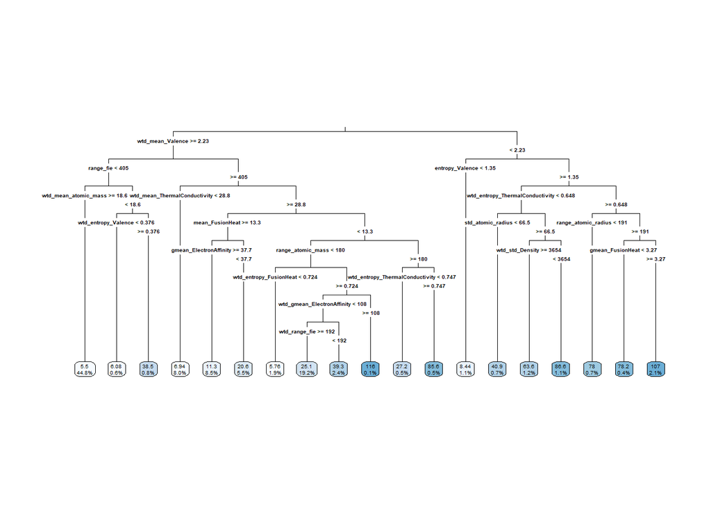

```
## [1] "mean absolute error for train data"
## [2] "6.36730987241146"
## [1] "mean absolute error for test data" "13.2578338585862"
```

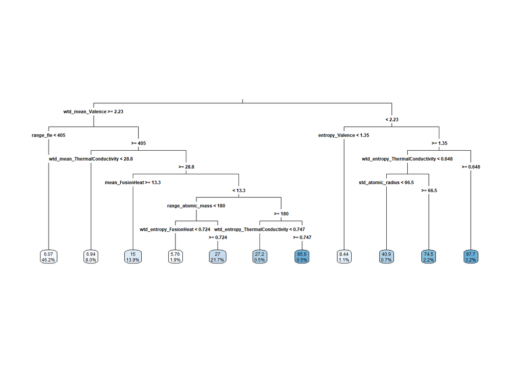

```
## [1] "mean absolute error for train data"
## [2] "7.16786086862858"
## [1] "mean absolute error for test data" "14.006293945671"
```

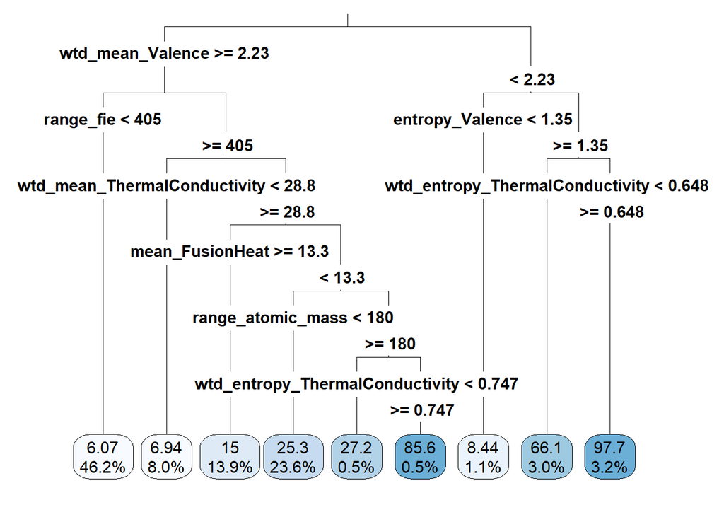

```
## [1] "mean absolute error for train data"
## [2] "7.61116997486661"
## [1] "mean absolute error for test data" "14.1963351840699"
```

```
## n= 5000
##
## node), split, n, deviance, yval
##       * denotes terminal node
##
##  1) root 5000 2585791.000 17.173100
##    2) wtd_mean_Valence>=2.229599 4637  945888.500 12.962490
##      4) range_fie< 404.95 2308  139674.100  6.074479 *
##      5) range_fie>=404.95 2329  588196.800 19.788400
##       10) wtd_mean_ThermalConductivity< 28.75795 399   19004.380  6.943992 *
##       11) wtd_mean_ThermalConductivity>=28.75795 1930  489757.200 22.443800
##         22) mean_FusionHeat>=13.28345 697   66801.980 14.978720 *
##         23) mean_FusionHeat< 13.28345 1233  362156.300 26.663720
##           46) range_atomic_mass< 179.8737 1179  244996.800 25.302990 *
##           47) range_atomic_mass>=179.8737 54   67313.950 56.372960
##             94) wtd_entropy_ThermalConductivity< 0.7472482 27   17393.190 27.166300 *
##             95) wtd_entropy_ThermalConductivity>=0.7472482 27    3857.176 85.579630 *
##    3) wtd_mean_Valence< 2.229599 363  507526.800 70.959870
##      6) entropy_Valence< 1.350551 56    8875.363  8.442023 *
##      7) entropy_Valence>=1.350551 307  239851.400 82.363780
##       14) wtd_entropy_ThermalConductivity< 0.6482988 149  102661.600 66.145230 *
##       15) wtd_entropy_ThermalConductivity>=0.6482988 158   61035.970 97.658480 *
```

```
## [1] "Visual representation of the cross-validation result"
```

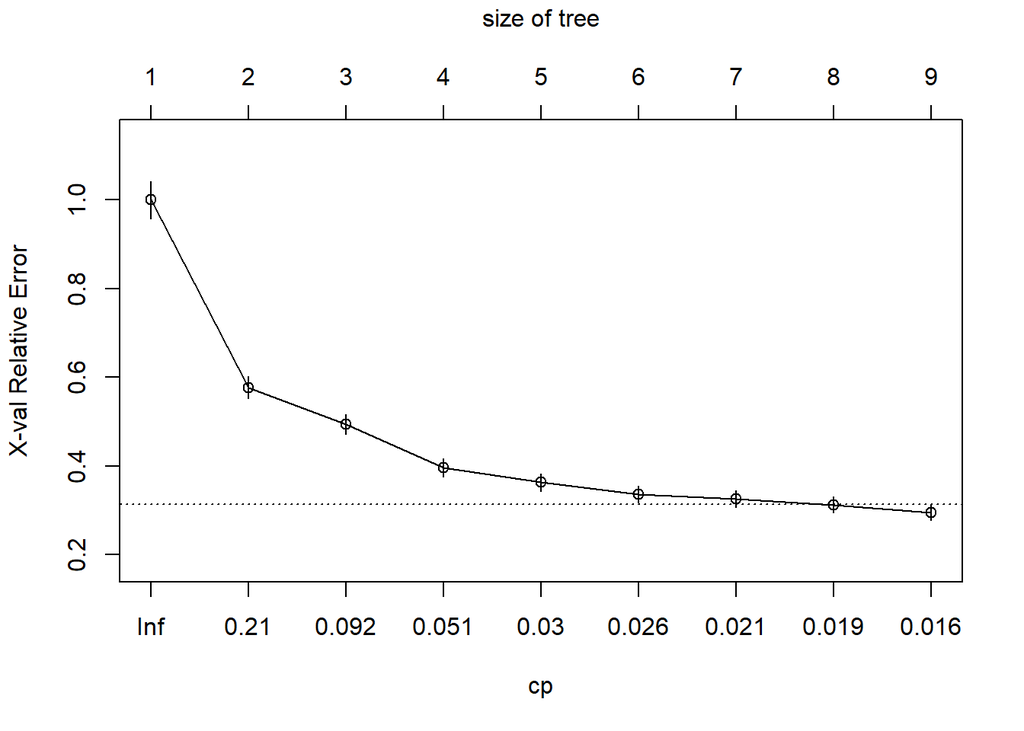

As can be seen the results given above, the decision tree for this particular regression dataset performs well with the minimal number of observations per tree leaf = 3 and the complexity parameter=0.005 (these values are based on our trials. As it can be seen from the above graph, there are better cp values for this model). Here, the performance metric is the mean absolute error which was calculated manually ( a function was written for this purpose, it can be seen from the Appendix-R Code part).

## 4.3. - Support Vector Machines

In this part, support vector machines was used to the regression analysis for this dataset. However, support vector machines took huge amount of time ( Waited more than 15 hours, it did not response). Therefore, the analysis was carried out based on only the Gaussian kernel. However, again, the support vector machine algorithm took huge amount of time. Therefore, the analysis was carried out for only single values of cost value ( the default value=1) since the cross validation did not response because of the great amount of computational load.

### 4.3.a. - Support Vector Machines for Polynomial Kernel

In this part, the code below tried to run but it did not response since the data was too big and this is the regression analysis. It has a huge computational load.

```
#Support Vector Machine for Polynomial Kernel
library(e1071)
set.seed(5)
svmfit<-svm(critical_temp~.,data = Dataset_3_train,kernel="polynomial")
print(svmfit)
#Finding best cost value
tuned<-tune(svm,critical_temp~.,data = Dataset_3_train,kernel="polynomial",ranges = list(cost=c(0.001,0.01,0.1,1,10,100)))
summary(tuned)
bestcost<-as.data.frame(tuned$best.parameters)
#Using best cost value
svmfit<-svm(critical_temp~.,data = Dataset_3_train,kernel="polynomial",cost=as.numeric(bestcost[1,1]))
print(svmfit)
#Predicting test data
p<-predict(svmfit,Dataset_3_test,type="class")
plot(p)

table(p,Dataset_3_test$class)
error<-1-sum(diag(table(p,Dataset_2_test$class))/sum(table(p,Dataset_2_test$class)))
print(c("test error",error))
```

### 4.3.b. - Support Vector Machines for Gaussian Kernel

The support vector machine algorithm was implemented the data on only a single cost value (default value=1) because of the huge computational load as discussed before. The results and the procedure can be seen below sequentially.

```
##
## Call:
## svm(formula = critical_temp ~ ., data = Dataset_3_train, kernel = "radial")
##
##
## Parameters:
##    SVM-Type:  eps-regression
##  SVM-Kernel:  radial
##        cost:  1
##       gamma:  0.01234568
##     epsilon:  0.1
##
##
## Number of Support Vectors:  2604
```

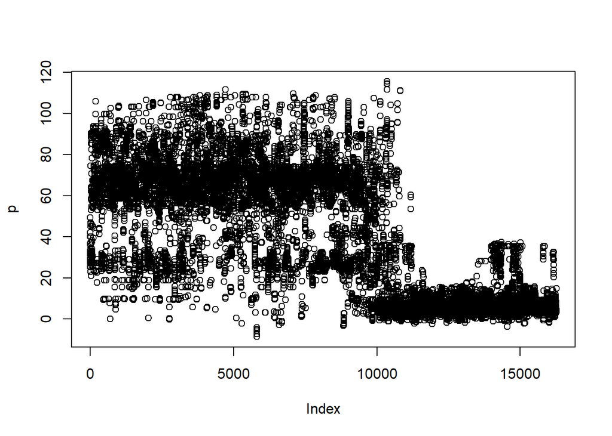

```
## [1] "coefficient of determination" "0.765271193974961"
```

After all the computations, the coefficient of determination was calculated for evaluating the performance. The result was close to 1 which means that the algorithm performs well on this dataset.

## 4.4. - Random Forest

In this part, again, the algorithm did not response for a long time for this regression data set. The code given below was tried to estimate the performance of the random forest algorithm on this particular data set, but it was stopped manually because of the too long computational time.

```
#Random Forest for Dataset 3

for (i in 1:5) {
  require(randomForest)
  library(cowplot)
  set.seed(5)
  # data.imputed<-rfImpute(V2~.,data=Dataset_1_train,iter=6) # for the data with NAs.

  model<-randomForest(critical_temp~.,data=Dataset_3_train,proximity=TRUE,mtry=10+i)
  print(model)
  error<-1-sum(diag(model$confusion)/sum(model$confusion))
  print(c("error",error))
}
#
set.seed(5)
model<-randomForest(critical_temp~.,data=Dataset_3_train,proximity=TRUE,mtry=15)
print(model)

error<-1-sum(diag(model$confusion)/sum(model$confusion))
print(c("train error",error))
#Predicting Test data - Error for Prediction of Test data
p<-predict(model,Dataset_3_test,type="class")
table(p,Dataset_3_test$critical_temp)
error<-1-sum(diag(table(p,Dataset_3_test$critical_temp))/sum(table(p,Dataset_3_test$critical_temp)))
print(c("test error",error))
```

## 4.5. - Stochastic Gradient Boosting (SGB)

Since the dataset 3 is a regression dataset, for the stochastic gradient boosting algorithm, the distribution type was selected as “Gaussian”. Then, again, different values of depth, learning rate and the number of trees were tried. After all, the best values of these parameters were obtained from the cross validation. Finally, the results train and the test error were obtained as can be seen below. Remember that, for the regression analyzes, the performance metric is again coefficient of determination. Therefore, the performance of this model can be evaluated based on the coefficient of determination.

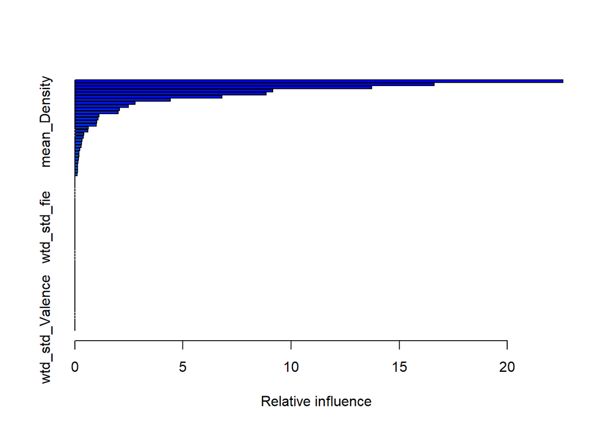

```
##                                                             var
## wtd_gmean_Valence                             wtd_gmean_Valence
## wtd_mean_Valence                               wtd_mean_Valence
## range_ThermalConductivity             range_ThermalConductivity
## range_atomic_radius                         range_atomic_radius
## wtd_entropy_atomic_mass                 wtd_entropy_atomic_mass
## gmean_Valence                                     gmean_Valence
## wtd_entropy_Valence                         wtd_entropy_Valence
## wtd_gmean_ElectronAffinity           wtd_gmean_ElectronAffinity
## range_fie                                             range_fie
## wtd_entropy_atomic_radius             wtd_entropy_atomic_radius
## wtd_std_ThermalConductivity         wtd_std_ThermalConductivity
## wtd_range_ThermalConductivity     wtd_range_ThermalConductivity
## gmean_ElectronAffinity                   gmean_ElectronAffinity
## mean_Density                                       mean_Density
## wtd_mean_atomic_mass                       wtd_mean_atomic_mass
## std_atomic_radius                             std_atomic_radius
## entropy_Valence                                 entropy_Valence
## range_ElectronAffinity                   range_ElectronAffinity
## wtd_mean_ThermalConductivity       wtd_mean_ThermalConductivity
## wtd_mean_ElectronAffinity             wtd_mean_ElectronAffinity
## std_ElectronAffinity                       std_ElectronAffinity
## wtd_entropy_FusionHeat                   wtd_entropy_FusionHeat
## wtd_gmean_ThermalConductivity     wtd_gmean_ThermalConductivity
## mean_FusionHeat                                 mean_FusionHeat
## wtd_range_atomic_mass                     wtd_range_atomic_mass
## wtd_std_atomic_radius                     wtd_std_atomic_radius
## mean_ThermalConductivity               mean_ThermalConductivity
## range_FusionHeat                               range_FusionHeat
## entropy_Density                                 entropy_Density
## wtd_range_FusionHeat                       wtd_range_FusionHeat
## gmean_Density                                     gmean_Density
## number_of_elements                           number_of_elements
## mean_atomic_mass                               mean_atomic_mass
## gmean_atomic_mass                             gmean_atomic_mass
## wtd_gmean_atomic_mass                     wtd_gmean_atomic_mass
## entropy_atomic_mass                         entropy_atomic_mass
## range_atomic_mass                             range_atomic_mass
## std_atomic_mass                                 std_atomic_mass
## wtd_std_atomic_mass                         wtd_std_atomic_mass
```

[output cut: 109 more lines]

```
## wtd_mean_FusionHeat              0.00000000
## gmean_FusionHeat                 0.00000000
## wtd_gmean_FusionHeat             0.00000000
## entropy_FusionHeat               0.00000000
## std_FusionHeat                   0.00000000
## wtd_std_FusionHeat               0.00000000
## gmean_ThermalConductivity        0.00000000
## entropy_ThermalConductivity      0.00000000
## wtd_entropy_ThermalConductivity  0.00000000
## std_ThermalConductivity          0.00000000
## mean_Valence                     0.00000000
## range_Valence                    0.00000000
## wtd_range_Valence                0.00000000
## std_Valence                      0.00000000
## wtd_std_Valence                  0.00000000
```

```
## [1] "coefficient of determination (train)"
## [2] "0.619339312551882"
```

```
## [1] "coefficient of determination (test)"
## [2] "0.662962770007723"
```

Here, the performance metric is coefficient of determination. Therefore error rates can be related with the coefficient of determination. We want coefficient of determination value to be close to 1. As can be seen from the results, the coefficient of determination of the cross validation on the train data is consistent with the coefficient of determination of the model on the test data. However, the model work better on the test data here, which implies that there is an underfitting case. Here, the coefficient of determination values are not too close to 1, but it is not bad for explaining the behavior of the data set.

# 5. Analyzes for Dataset 4

## 5.1. - Penalized Regression Approach

In this part, penalized regression was used to predict the response of this data set (there are 10 different classes to predict). First of all, cross validation procedure was carried out on the train data set and this worked properly. After the cross validation, the optimum value of the lambda was obtained and this value was used on the model. Although the best parameter value was used on the model, the model tries to predict one of the class very frequently. Therefore, the results are not realistic. All the procedure and the confusion matrices can be seen below.

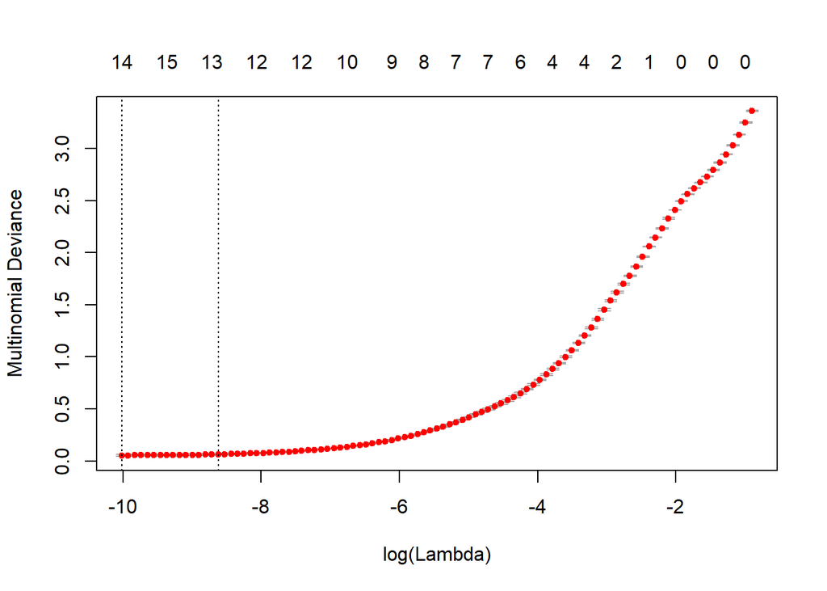

```
##            Length Class  Mode
## a0         10     -none- numeric
## beta       10     -none- list
## dfmat      10     -none- numeric
## df          1     -none- numeric
## dim         2     -none- numeric
## lambda      1     -none- numeric
## dev.ratio   1     -none- numeric
## nulldev     1     -none- numeric
## npasses     1     -none- numeric
## jerr        1     -none- numeric
## offset      1     -none- logical
## classnames 10     -none- character
## grouped     1     -none- logical
## call        6     -none- call
## nobs        1     -none- numeric
```

```
## [1] "confusion matrix for the train data"
```

```
##
##                          AdenomeraAndre AdenomeraHylaedactylus
##   AdenomeraHylaedactylus              0                    231
##   HylaMinuta                          0                      0
##   HypsiboasCordobae                   0                      0
##   LeptodactylusFuscus                 0                      3
##   OsteocephalusOophagus               0                      0
##   Rhinellagranulosa                   0                    458
##   ScinaxRuber                       499                   1927
##
##                          Ameeregatrivittata HylaMinuta
##   AdenomeraHylaedactylus                  0          3
##   HylaMinuta                              0          1
##   HypsiboasCordobae                       0          0
##   LeptodactylusFuscus                     0          4
##   OsteocephalusOophagus                   0          0
##   Rhinellagranulosa                       4        109
##   ScinaxRuber                           400        107
##
##                          HypsiboasCinerascens HypsiboasCordobae
##   AdenomeraHylaedactylus                    0                 1
##   HylaMinuta                                0                 0
##   HypsiboasCordobae                         0                 2
##   LeptodactylusFuscus                       0                 1
##   OsteocephalusOophagus                    10                 0
##   Rhinellagranulosa                        96               136
##   ScinaxRuber                             229               718
##
##                          LeptodactylusFuscus OsteocephalusOophagus
##   AdenomeraHylaedactylus                   1                     0
##   HylaMinuta                               0                     0
##   HypsiboasCordobae                        0                     0
##   LeptodactylusFuscus                      0                     0
##   OsteocephalusOophagus                    0                     0
##   Rhinellagranulosa                       16                     6
##   ScinaxRuber                            183                    88
##
##                          Rhinellagranulosa ScinaxRuber
##   AdenomeraHylaedactylus                 1           2
##   HylaMinuta                             0           0
##   HypsiboasCordobae                      0           1
##   LeptodactylusFuscus                    0           2
##   OsteocephalusOophagus                  0           1
##   Rhinellagranulosa                      1          42
##   ScinaxRuber                           51          62
```

```
## [1] "confusion matrix for the test data"
```

```
##
##                          AdenomeraAndre AdenomeraHylaedactylus
##   AdenomeraHylaedactylus              0                     60
##   HylaMinuta                          0                      0
##   LeptodactylusFuscus                 0                      0
##   OsteocephalusOophagus               0                      0
##   Rhinellagranulosa                   0                    165
##   ScinaxRuber                       173                    634
##
##                          Ameeregatrivittata HylaMinuta
##   AdenomeraHylaedactylus                  0          1
##   HylaMinuta                              0          1
##   LeptodactylusFuscus                     0          2
##   OsteocephalusOophagus                   0          0
##   Rhinellagranulosa                       2         46
##   ScinaxRuber                           136         36
##
##                          HypsiboasCinerascens HypsiboasCordobae
##   AdenomeraHylaedactylus                    0                 0
##   HylaMinuta                                0                 0
##   LeptodactylusFuscus                       1                 0
##   OsteocephalusOophagus                     4                 0
##   Rhinellagranulosa                        33                33
##   ScinaxRuber                              99               230
##
##                          LeptodactylusFuscus OsteocephalusOophagus
##   AdenomeraHylaedactylus                   0                     0
##   HylaMinuta                               0                     0
##   LeptodactylusFuscus                      0                     0
##   OsteocephalusOophagus                    0                     0
##   Rhinellagranulosa                        3                     3
##   ScinaxRuber                             67                    17
##
##                          Rhinellagranulosa ScinaxRuber
##   AdenomeraHylaedactylus                 0           1
##   HylaMinuta                             0           0
##   LeptodactylusFuscus                    0           2
##   OsteocephalusOophagus                  0           1
##   Rhinellagranulosa                      0          12
##   ScinaxRuber                           15          22
```

As can be seen from the results (also it was seen on the 2nd dataset), this algorithm does not work properly on the datasets with more than 2 classes.

## 5.2. - Decision Tree

In this part, decision tree algorithm was used for the classification purpose. First of all, cross validation was made for the dataset on differen cp values. Then the model was created and tried for 4 different minbucket values (4,5,6,7) and 4 different complexity parameter values (0.01,0.015,0.02,0.025) respectively. The results, summary of the decision tree model, train and test errors, and the visual representation of the cross-validation result can be observed below.

```
##
## Classification tree:
## rpart(formula = Species ~ ., data = Dataset_4_train, method = "class",
##     control = rpart.control(minbucket = 2 + i, cp = 0.005 * i))
##
## Variables actually used in tree construction:
## [1] Family   Genus    MFCCs_13 MFCCs_22 RecordID
##
## Root node error: 2777/5396 = 0.51464
##
## n= 5396
##
##          CP nsplit rel error   xerror      xstd
## 1  0.247029      0 1.0000000 1.000000 0.0132204
## 2  0.163486      1 0.7529708 0.751891 0.0128836
## 3  0.137559      2 0.5894851 0.589485 0.0121604
## 4  0.120274      3 0.4519265 0.455167 0.0112032
## 5  0.072020      4 0.3316529 0.334894 0.0099905
## 6  0.068419      5 0.2596327 0.277638 0.0092570
## 7  0.038891      6 0.1912135 0.194815 0.0079448
## 8  0.034210      7 0.1523227 0.162405 0.0073208
## 9  0.033129      8 0.1181131 0.134318 0.0067100
## 10 0.027728      9 0.0849838 0.099028 0.0058174
## 11 0.019085     10 0.0572560 0.061937 0.0046468
## 12 0.016205     11 0.0381707 0.041051 0.0038040
## 13 0.012243     12 0.0219662 0.024127 0.0029292
## 14 0.010000     13 0.0097227 0.010083 0.0019005
```

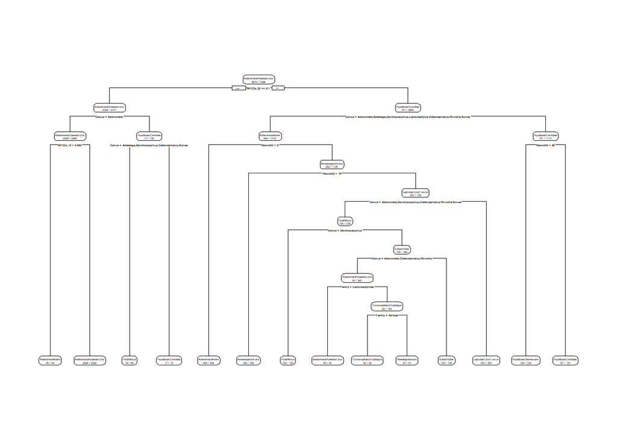

```
## [1] "trainerror"          "0.00500370644922166"
## [1] "test error"          "0.00444691495275151"
##
## Classification tree:
## rpart(formula = Species ~ ., data = Dataset_4_train, method = "class",
##     control = rpart.control(minbucket = 2 + i, cp = 0.005 * i))
##
## Variables actually used in tree construction:
## [1] Family   Genus    MFCCs_13 MFCCs_22 RecordID
##
## Root node error: 2777/5396 = 0.51464
##
## n= 5396
##
##          CP nsplit rel error   xerror      xstd
## 1  0.247029      0  1.000000 1.000000 0.0132204
## 2  0.163486      1  0.752971 0.751891 0.0128836
## 3  0.137559      2  0.589485 0.589485 0.0121604
## 4  0.120274      3  0.451927 0.455167 0.0112032
## 5  0.072020      4  0.331653 0.334894 0.0099905
## 6  0.068419      5  0.259633 0.277638 0.0092570
## 7  0.038891      6  0.191214 0.194815 0.0079448
## 8  0.034210      7  0.152323 0.162405 0.0073208
## 9  0.033129      8  0.118113 0.134318 0.0067100
## 10 0.027728      9  0.084984 0.099028 0.0058174
## 11 0.019085     10  0.057256 0.061937 0.0046468
## 12 0.016205     11  0.038171 0.041051 0.0038040
## 13 0.015000     12  0.021966 0.025567 0.0030142
```

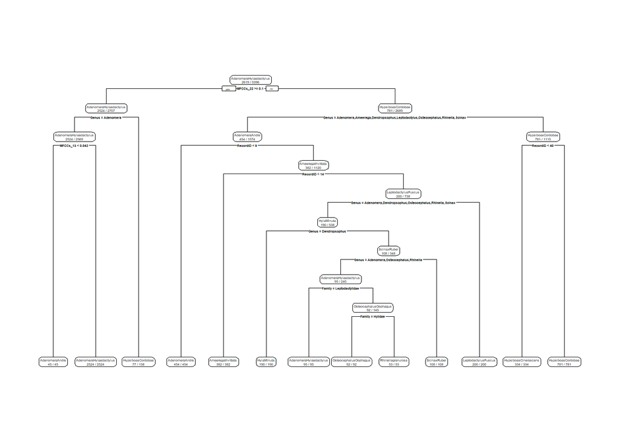

```
## [1] "trainerror"         "0.0113046701260193"
## [1] "test error"         "0.0111172873818788"
##
## Classification tree:
## rpart(formula = Species ~ ., data = Dataset_4_train, method = "class",
##     control = rpart.control(minbucket = 2 + i, cp = 0.005 * i))
##
## Variables actually used in tree construction:
## [1] Family   Genus    MFCCs_22 RecordID
##
## Root node error: 2777/5396 = 0.51464
##
## n= 5396
##
##          CP nsplit rel error   xerror      xstd
## 1  0.247029      0  1.000000 1.000000 0.0132204
## 2  0.163486      1  0.752971 0.751891 0.0128836
## 3  0.137559      2  0.589485 0.589485 0.0121604
## 4  0.120274      3  0.451927 0.455167 0.0112032
## 5  0.072020      4  0.331653 0.334894 0.0099905
## 6  0.068419      5  0.259633 0.277638 0.0092570
## 7  0.038891      6  0.191214 0.194815 0.0079448
## 8  0.034210      7  0.152323 0.162405 0.0073208
## 9  0.033129      8  0.118113 0.134318 0.0067100
## 10 0.027728      9  0.084984 0.099028 0.0058174
## 11 0.020000     10  0.057256 0.061937 0.0046468
```

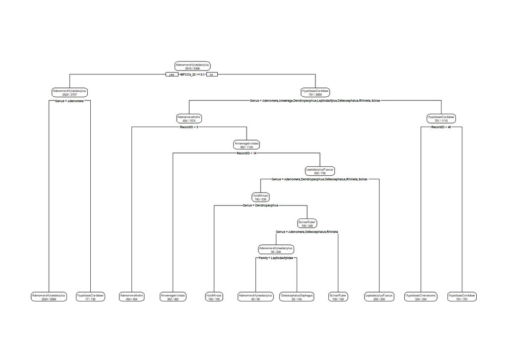

```
## [1] "trainerror"        "0.029466271312083"
## [1] "test error"         "0.0300166759310728"
##
## Classification tree:
## rpart(formula = Species ~ ., data = Dataset_4_train, method = "class",
##     control = rpart.control(minbucket = 2 + i, cp = 0.005 * i))
##
## Variables actually used in tree construction:
## [1] Family   Genus    MFCCs_22 RecordID
##
## Root node error: 2777/5396 = 0.51464
##
## n= 5396
##
##          CP nsplit rel error   xerror      xstd
## 1  0.247029      0  1.000000 1.000000 0.0132204
## 2  0.163486      1  0.752971 0.751891 0.0128836
## 3  0.137559      2  0.589485 0.589485 0.0121604
## 4  0.120274      3  0.451927 0.455167 0.0112032
## 5  0.072020      4  0.331653 0.334894 0.0099905
## 6  0.068419      5  0.259633 0.277638 0.0092570
## 7  0.038891      6  0.191214 0.194815 0.0079448
## 8  0.034210      7  0.152323 0.162405 0.0073208
## 9  0.033129      8  0.118113 0.134318 0.0067100
## 10 0.027728      9  0.084984 0.099028 0.0058174
## 11 0.025000     10  0.057256 0.073461 0.0050451
```

```
## [1] "trainerror"        "0.029466271312083"
## [1] "test error"         "0.0300166759310728"
```

```
## [1] "Visual representation of the cross-validation result"
```

```
##
## Classification tree:
## rpart(formula = Species ~ ., data = Dataset_4_train, method = "class",
##     control = rpart.control(minbucket = 2 + i, cp = 0.005 * i))
##
## Variables actually used in tree construction:
## [1] Family   Genus    MFCCs_22 RecordID
##
## Root node error: 2777/5396 = 0.51464
##
## n= 5396
##
##          CP nsplit rel error   xerror      xstd
## 1  0.247029      0  1.000000 1.000000 0.0132204
## 2  0.163486      1  0.752971 0.751891 0.0128836
## 3  0.137559      2  0.589485 0.589485 0.0121604
## 4  0.120274      3  0.451927 0.455167 0.0112032
## 5  0.072020      4  0.331653 0.334894 0.0099905
## 6  0.068419      5  0.259633 0.277638 0.0092570
## 7  0.038891      6  0.191214 0.194815 0.0079448
## 8  0.034210      7  0.152323 0.162405 0.0073208
## 9  0.033129      8  0.118113 0.134318 0.0067100
## 10 0.027728      9  0.084984 0.099028 0.0058174
## 11 0.025000     10  0.057256 0.073461 0.0050451
```

```
## [1] "cp values for error rates"
```

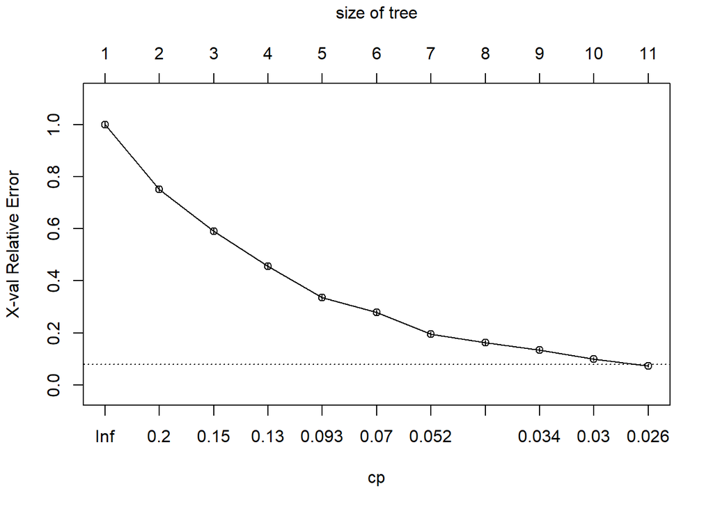

As can be seen from the results, while the complexity parameter and the minbucket values are increasing together, the train and test errors are also increasing. Therefore it can be said that the better values compared to other trials for this dataset are 0.01 for complexity parameter and 4 for the minbucket value which gives the minimum error rate compared to other values (these values are based on our trials. As it can be seen from the above graph, there are better cp values for this model). The train and the test error rates seem to be consistent. Moreover, both train and the test error rates were calculated after creating the confusion matrices.

## 5.3. - Support Vector Machines

The support vector machine technique was implemented for both polynomial and the Gaussian kernel type seperately.

### 5.3.a. - Support Vector Machines for Polynomial Kernel

In this part, the procedure with polynomial kernel was first implemented on the train data and cross validation was used so that the optimum parameter values can be obtained. Then the model was created with the best parameter values and used on the test data. After all, the results, confusion matrix and the test error can be obtained below. All the procedures can be followed below sequentially.

```
##
## Call:
## svm(formula = Species ~ ., data = Dataset_4_train, kernel = "polynomial",
##     cost = 0.1)
##
##
## Parameters:
##    SVM-Type:  C-classification
##  SVM-Kernel:  polynomial
##        cost:  0.1
##      degree:  3
##       gamma:  0.02941176
##      coef.0:  0
##
## Number of Support Vectors:  2166
```

```
##
## Parameter tuning of 'svm':
##
## - sampling method: 10-fold cross validation
##
## - best parameters:
##  cost
##   100
##
## - best performance: 0.00481722
##
## - Detailed performance results:
##    cost       error  dispersion
## 1 1e-03 0.513881674 0.025810450
## 2 1e-02 0.325968872 0.022762679
## 3 1e-01 0.058001443 0.012266814
## 4 1e+00 0.010745894 0.006460382
## 5 1e+01 0.004817563 0.003621092
## 6 1e+02 0.004817220 0.003824949
```

```
##
## Call:
## svm(formula = Species ~ ., data = Dataset_4_train, kernel = "polynomial",
##     cost = as.numeric(bestcost[1, 1]))
##
##
## Parameters:
##    SVM-Type:  C-classification
##  SVM-Kernel:  polynomial
##        cost:  100
##      degree:  3
##       gamma:  0.02941176
##      coef.0:  0
##
## Number of Support Vectors:  333
```

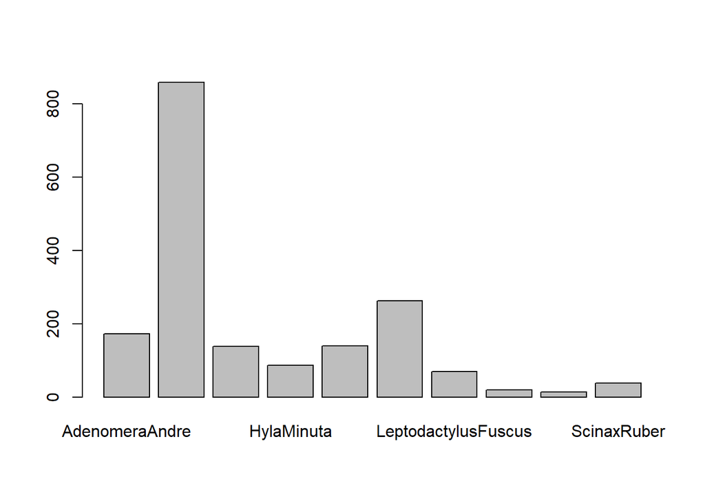

```
##
## p                        AdenomeraAndre AdenomeraHylaedactylus
##   AdenomeraAndre                    173                      0
##   AdenomeraHylaedactylus              0                    859
##   Ameeregatrivittata                  0                      0
##   HylaMinuta                          0                      0
##   HypsiboasCinerascens                0                      0
##   HypsiboasCordobae                   0                      0
##   LeptodactylusFuscus                 0                      0
##   OsteocephalusOophagus               0                      0
##   Rhinellagranulosa                   0                      0
##   ScinaxRuber                         0                      0
##
## p                        Ameeregatrivittata HylaMinuta
##   AdenomeraAndre                          0          0
##   AdenomeraHylaedactylus                  0          0
##   Ameeregatrivittata                    138          0
##   HylaMinuta                              0         86
##   HypsiboasCinerascens                    0          0
##   HypsiboasCordobae                       0          0
##   LeptodactylusFuscus                     0          0
##   OsteocephalusOophagus                   0          0
##   Rhinellagranulosa                       0          0
##   ScinaxRuber                             0          0
##
## p                        HypsiboasCinerascens HypsiboasCordobae
##   AdenomeraAndre                            0                 0
##   AdenomeraHylaedactylus                    0                 0
##   Ameeregatrivittata                        0                 0
##   HylaMinuta                                0                 1
##   HypsiboasCinerascens                    137                 1
##   HypsiboasCordobae                         0               261
##   LeptodactylusFuscus                       0                 0
##   OsteocephalusOophagus                     0                 0
##   Rhinellagranulosa                         0                 0
##   ScinaxRuber                               0                 0
##
## p                        LeptodactylusFuscus OsteocephalusOophagus
##   AdenomeraAndre                           0                     0
##   AdenomeraHylaedactylus                   0                     0
##   Ameeregatrivittata                       0                     0
##   HylaMinuta                               0                     0
##   HypsiboasCinerascens                     0                     1
##   HypsiboasCordobae                        1                     0
##   LeptodactylusFuscus                     69                     0
##   OsteocephalusOophagus                    0                    19
##   Rhinellagranulosa                        0                     0
##   ScinaxRuber                              0                     0
##
## p                        Rhinellagranulosa ScinaxRuber
##   AdenomeraAndre                         0           0
##   AdenomeraHylaedactylus                 0           0
##   Ameeregatrivittata                     0           0
##   HylaMinuta                             0           0
##   HypsiboasCinerascens                   1           0
##   HypsiboasCordobae                      0           0
##   LeptodactylusFuscus                    0           0
##   OsteocephalusOophagus                  0           0
##   Rhinellagranulosa                     14           0
##   ScinaxRuber                            0          38
```

```
## [1] "test error"         "0.0027793218454697"
```

### 5.3.b. - Support Vector Machines for Gaussian Kernel

In this part, again, the procedure was first implemented on the train data so that the optimum parameter values can be obtained. Then the model was created and used on the test data. After all, the results, confusion matrix and the test error can be seen below.

```
##
## Call:
## svm(formula = Species ~ ., data = Dataset_4_train, kernel = "radial",
##     cost = 0.1)
##
##
## Parameters:
##    SVM-Type:  C-classification
##  SVM-Kernel:  radial
##        cost:  0.1
##       gamma:  0.02941176
##
## Number of Support Vectors:  1398
```

```
##
## Parameter tuning of 'svm':
##
## - sampling method: 10-fold cross validation
##
## - best parameters:
##  cost
##     1
##
## - best performance: 0.003890607
##
## - Detailed performance results:
##    cost       error  dispersion
## 1 1e-03 0.514623102 0.025739122
## 2 1e-02 0.144543737 0.020962037
## 3 1e-01 0.020568611 0.005477961
## 4 1e+00 0.003890607 0.002953110
## 5 1e+01 0.003890950 0.002381978
## 6 1e+02 0.003890950 0.002381978
```

```
##
## Call:
## svm(formula = Species ~ ., data = Dataset_4_train, kernel = "radial",
##     cost = as.numeric(bestcost[1, 1]))
##
##
## Parameters:
##    SVM-Type:  C-classification
##  SVM-Kernel:  radial
##        cost:  1
##       gamma:  0.02941176
##
## Number of Support Vectors:  649
```

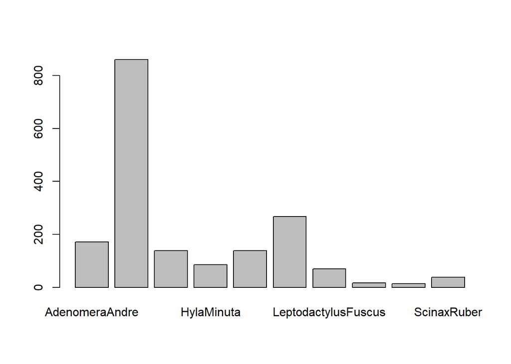

```
##
## p                        AdenomeraAndre AdenomeraHylaedactylus
##   AdenomeraAndre                    172                      0
##   AdenomeraHylaedactylus              0                    859
##   Ameeregatrivittata                  0                      0
##   HylaMinuta                          0                      0
##   HypsiboasCinerascens                0                      0
##   HypsiboasCordobae                   1                      0
##   LeptodactylusFuscus                 0                      0
##   OsteocephalusOophagus               0                      0
##   Rhinellagranulosa                   0                      0
##   ScinaxRuber                         0                      0
##
## p                        Ameeregatrivittata HylaMinuta
##   AdenomeraAndre                          0          0
##   AdenomeraHylaedactylus                  0          1
##   Ameeregatrivittata                    138          0
##   HylaMinuta                              0         85
##   HypsiboasCinerascens                    0          0
##   HypsiboasCordobae                       0          0
##   LeptodactylusFuscus                     0          0
##   OsteocephalusOophagus                   0          0
##   Rhinellagranulosa                       0          0
##   ScinaxRuber                             0          0
##
## p                        HypsiboasCinerascens HypsiboasCordobae
##   AdenomeraAndre                            0                 0
##   AdenomeraHylaedactylus                    0                 0
##   Ameeregatrivittata                        0                 0
##   HylaMinuta                                0                 0
##   HypsiboasCinerascens                    137                 0
##   HypsiboasCordobae                         0               263
##   LeptodactylusFuscus                       0                 0
##   OsteocephalusOophagus                     0                 0
##   Rhinellagranulosa                         0                 0
##   ScinaxRuber                               0                 0
##
## p                        LeptodactylusFuscus OsteocephalusOophagus
##   AdenomeraAndre                           0                     0
##   AdenomeraHylaedactylus                   0                     0
##   Ameeregatrivittata                       0                     0
##   HylaMinuta                               0                     0
##   HypsiboasCinerascens                     0                     2
##   HypsiboasCordobae                        1                     1
##   LeptodactylusFuscus                     69                     0
##   OsteocephalusOophagus                    0                    17
##   Rhinellagranulosa                        0                     0
##   ScinaxRuber                              0                     0
##
## p                        Rhinellagranulosa ScinaxRuber
##   AdenomeraAndre                         0           0
##   AdenomeraHylaedactylus                 0           0
##   Ameeregatrivittata                     0           0
##   HylaMinuta                             0           0
##   HypsiboasCinerascens                   0           0
##   HypsiboasCordobae                      1           0
##   LeptodactylusFuscus                    0           0
##   OsteocephalusOophagus                  0           0
##   Rhinellagranulosa                     14           0
##   ScinaxRuber                            0          38
```

```
## [1] "test error"          "0.00389105058365757"
```

## 5.4. - Random Forest

In this task, the values (3,4,5) for the number of variables randomly sampled as candidates at each split (i.e. “m”) were tried in each iteration respectively. Then the best value of m was obtained from the iterations (The best value of the m was found to be 5). The results, train error, test error and the confusion matrices can be seen below.

```
##
## Call:
##  randomForest(formula = Species ~ ., data = Dataset_4_train, proximity = TRUE,      mtry = 2 + i)
##                Type of random forest: classification
##                      Number of trees: 500
## No. of variables tried at each split: 3
##
##         OOB estimate of  error rate: 0.5%
## Confusion matrix:
##                        AdenomeraAndre AdenomeraHylaedactylus
## AdenomeraAndre                    496                      0
## AdenomeraHylaedactylus              0                   2616
## Ameeregatrivittata                  0                      0
## HylaMinuta                          0                      0
## HypsiboasCinerascens                0                      0
## HypsiboasCordobae                   0                      0
## LeptodactylusFuscus                 0                      0
## OsteocephalusOophagus               0                      0
## Rhinellagranulosa                   0                      0
## ScinaxRuber                         0                      0
##                        Ameeregatrivittata HylaMinuta HypsiboasCinerascens
## AdenomeraAndre                          0          0                    2
## AdenomeraHylaedactylus                  1          0                    2
## Ameeregatrivittata                    404          0                    0
## HylaMinuta                              1        223                    0
## HypsiboasCinerascens                    0          0                  332
## HypsiboasCordobae                       0          0                    0
## LeptodactylusFuscus                     0          1                    0
## OsteocephalusOophagus                   0          0                    2
## Rhinellagranulosa                       1          0                    0
## ScinaxRuber                             0          1                    0
##                        HypsiboasCordobae LeptodactylusFuscus
## AdenomeraAndre                         1                   0
## AdenomeraHylaedactylus                 0                   0
## Ameeregatrivittata                     0                   0
## HylaMinuta                             0                   0
## HypsiboasCinerascens                   3                   0
## HypsiboasCordobae                    857                   0
## LeptodactylusFuscus                    2                 196
## OsteocephalusOophagus                  1                   1
```

[output cut: 140 more lines]

```
## OsteocephalusOophagus                     93                 0           0
## Rhinellagranulosa                          0                50           0
## ScinaxRuber                                0                 0         109
##                         class.error
## AdenomeraAndre         0.0020040080
## AdenomeraHylaedactylus 0.0007636502
## Ameeregatrivittata     0.0000000000
## HylaMinuta             0.0000000000
## HypsiboasCinerascens   0.0029850746
## HypsiboasCordobae      0.0000000000
## LeptodactylusFuscus    0.0100000000
## OsteocephalusOophagus  0.0106382979
## Rhinellagranulosa      0.0566037736
## ScinaxRuber            0.0090909091
## [1] "error"               "0.00205557754338659"
```

```
##
## Call:
##  randomForest(formula = Species ~ ., data = Dataset_4_train, proximity = TRUE,      mtry = 5)
##                Type of random forest: classification
##                      Number of trees: 500
## No. of variables tried at each split: 5
##
##         OOB estimate of  error rate: 0.2%
## Confusion matrix:
##                        AdenomeraAndre AdenomeraHylaedactylus
## AdenomeraAndre                    498                      0
## AdenomeraHylaedactylus              0                   2617
## Ameeregatrivittata                  0                      0
## HylaMinuta                          0                      0
## HypsiboasCinerascens                0                      0
## HypsiboasCordobae                   0                      0
## LeptodactylusFuscus                 0                      0
## OsteocephalusOophagus               0                      0
## Rhinellagranulosa                   0                      0
## ScinaxRuber                         0                      0
##                        Ameeregatrivittata HylaMinuta HypsiboasCinerascens
## AdenomeraAndre                          0          0                    1
## AdenomeraHylaedactylus                  1          0                    1
## Ameeregatrivittata                    404          0                    0
## HylaMinuta                              0        224                    0
## HypsiboasCinerascens                    0          0                  334
## HypsiboasCordobae                       0          0                    0
## LeptodactylusFuscus                     0          1                    0
## OsteocephalusOophagus                   0          0                    0
## Rhinellagranulosa                       0          0                    0
## ScinaxRuber                             0          0                    0
##                        HypsiboasCordobae LeptodactylusFuscus
## AdenomeraAndre                         0                   0
## AdenomeraHylaedactylus                 0                   0
## Ameeregatrivittata                     0                   0
## HylaMinuta                             0                   0
## HypsiboasCinerascens                   1                   0
## HypsiboasCordobae                    858                   0
## LeptodactylusFuscus                    0                 198
## OsteocephalusOophagus                  1                   0
```

[output cut: 9 more lines]

```
## LeptodactylusFuscus                        1                 0           0
## OsteocephalusOophagus                     93                 0           0
## Rhinellagranulosa                          0                50           0
## ScinaxRuber                                0                 0         109
##                         class.error
## AdenomeraAndre         0.0020040080
## AdenomeraHylaedactylus 0.0007636502
## Ameeregatrivittata     0.0000000000
## HylaMinuta             0.0000000000
## HypsiboasCinerascens   0.0029850746
## HypsiboasCordobae      0.0000000000
## LeptodactylusFuscus    0.0100000000
## OsteocephalusOophagus  0.0106382979
## Rhinellagranulosa      0.0566037736
## ScinaxRuber            0.0090909091
```

```
## [1] "train error"         "0.00205557754338659"
```

```
##
## p                        AdenomeraAndre AdenomeraHylaedactylus
##   AdenomeraAndre                    173                      0
##   AdenomeraHylaedactylus              0                    859
##   Ameeregatrivittata                  0                      0
##   HylaMinuta                          0                      0
##   HypsiboasCinerascens                0                      0
##   HypsiboasCordobae                   0                      0
##   LeptodactylusFuscus                 0                      0
##   OsteocephalusOophagus               0                      0
##   Rhinellagranulosa                   0                      0
##   ScinaxRuber                         0                      0
##
## p                        Ameeregatrivittata HylaMinuta
##   AdenomeraAndre                          0          0
##   AdenomeraHylaedactylus                  0          0
##   Ameeregatrivittata                    138          0
##   HylaMinuta                              0         86
##   HypsiboasCinerascens                    0          0
##   HypsiboasCordobae                       0          0
##   LeptodactylusFuscus                     0          0
##   OsteocephalusOophagus                   0          0
##   Rhinellagranulosa                       0          0
##   ScinaxRuber                             0          0
##
## p                        HypsiboasCinerascens HypsiboasCordobae
##   AdenomeraAndre                            0                 0
##   AdenomeraHylaedactylus                    0                 0
##   Ameeregatrivittata                        0                 0
##   HylaMinuta                                0                 0
##   HypsiboasCinerascens                    137                 0
##   HypsiboasCordobae                         0               263
##   LeptodactylusFuscus                       0                 0
##   OsteocephalusOophagus                     0                 0
##   Rhinellagranulosa                         0                 0
##   ScinaxRuber                               0                 0
##
## p                        LeptodactylusFuscus OsteocephalusOophagus
##   AdenomeraAndre                           0                     0
##   AdenomeraHylaedactylus                   0                     0
##   Ameeregatrivittata                       0                     0
##   HylaMinuta                               0                     0
##   HypsiboasCinerascens                     0                     0
##   HypsiboasCordobae                        1                     0
##   LeptodactylusFuscus                     69                     0
##   OsteocephalusOophagus                    0                    20
##   Rhinellagranulosa                        0                     0
##   ScinaxRuber                              0                     0
##
## p                        Rhinellagranulosa ScinaxRuber
##   AdenomeraAndre                         0           0
##   AdenomeraHylaedactylus                 0           0
##   Ameeregatrivittata                     0           0
##   HylaMinuta                             0           0
##   HypsiboasCinerascens                   0           0
##   HypsiboasCordobae                      0           0
##   LeptodactylusFuscus                    0           0
##   OsteocephalusOophagus                  1           0
##   Rhinellagranulosa                     14           0
##   ScinaxRuber                            0          38
```

```
## [1] "test error"          "0.00111172873818788"
```

After completing the implementation, train error was found as 0.0021 while the test error was found as 0.0011, which means that this algorithm performs well on this dataset. For these values, the model works better on the test data. Although the random forest algorithm tries to find the best parameter values, here, the test data works better. For the larger m values, the error rates approach to zero. The performance metric is confusion matrix and the error rates were calculated based on the confusion matrix created by using the model with these parameters.

## 5.5. - Stochastic Gradient Boosting (SGB)

In this part, different values of depth, learning rate and the number of trees were tried for estimating the 10 different classes. Here, the distribution type for the stochastic gradient boosting technique was selected as multinomial since the aim is classification here. After all, the best values of these parameters were obtained from the cross validation. Note that, after the implementation of the procedure, the model gives the result in the probability format. After converting these probability data to the categorical results, the confusion matrices were created and the error rates were calculated these matrices. Finally, the results, train and the test error were obtained as can be seen below. Finally, the results, confusion matrices, train and the test error were obtained as can be seen below.

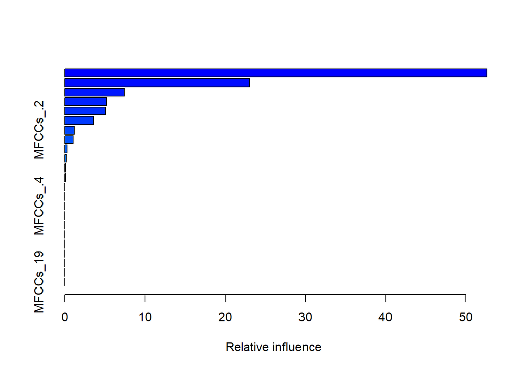

```
##               var     rel.inf
## RecordID RecordID 52.61059737
## MFCCs_22 MFCCs_22 23.06198153
## MFCCs_15 MFCCs_15  7.46640839
## MFCCs_12 MFCCs_12  5.19648728
## MFCCs_13 MFCCs_13  5.08199929
## MFCCs_11 MFCCs_11  3.54484999
## MFCCs_.2 MFCCs_.2  1.22963366
## MFCCs_17 MFCCs_17  1.08105041
## MFCCs_10 MFCCs_10  0.30977924
## MFCCs_.5 MFCCs_.5  0.21098544
## MFCCs_21 MFCCs_21  0.12381198
## MFCCs_20 MFCCs_20  0.08241544
## MFCCs_.1 MFCCs_.1  0.00000000
## MFCCs_.3 MFCCs_.3  0.00000000
## MFCCs_.4 MFCCs_.4  0.00000000
## MFCCs_.6 MFCCs_.6  0.00000000
## MFCCs_.7 MFCCs_.7  0.00000000
## MFCCs_.8 MFCCs_.8  0.00000000
## MFCCs_.9 MFCCs_.9  0.00000000
## MFCCs_14 MFCCs_14  0.00000000
## MFCCs_16 MFCCs_16  0.00000000
## MFCCs_18 MFCCs_18  0.00000000
## MFCCs_19 MFCCs_19  0.00000000
```

```
## [1] "confusion matrix for train data"
```

```
##
##                              AdenomeraAndre AdenomeraHylaedactylus
##   AdenomeraAndre.100                    499                      0
##   AdenomeraHylaedactylus.100              0                   2619
##   Ameeregatrivittata.100                  0                      0
##   HylaMinuta.100                          0                      0
##   HypsiboasCinerascens.100                0                      0
##   HypsiboasCordobae.100                   0                      0
##   LeptodactylusFuscus.100                 0                      0
##   OsteocephalusOophagus.100               0                      0
##   Rhinellagranulosa.100                   0                      0
##   ScinaxRuber.100                         0                      0
##
##                              Ameeregatrivittata HylaMinuta
##   AdenomeraAndre.100                          0          0
##   AdenomeraHylaedactylus.100                  0          1
##   Ameeregatrivittata.100                    404          0
##   HylaMinuta.100                              0        223
##   HypsiboasCinerascens.100                    0          0
##   HypsiboasCordobae.100                       0          0
##   LeptodactylusFuscus.100                     0          0
##   OsteocephalusOophagus.100                   0          0
##   Rhinellagranulosa.100                       0          0
##   ScinaxRuber.100                             0          0
##
##                              HypsiboasCinerascens HypsiboasCordobae
##   AdenomeraAndre.100                            0                 0
##   AdenomeraHylaedactylus.100                    0                 0
##   Ameeregatrivittata.100                        0                 0
##   HylaMinuta.100                                0                 0
##   HypsiboasCinerascens.100                    335                 0
##   HypsiboasCordobae.100                         0               858
##   LeptodactylusFuscus.100                       0                 0
##   OsteocephalusOophagus.100                     0                 0
##   Rhinellagranulosa.100                         0                 0
##   ScinaxRuber.100                               0                 0
##
##                              LeptodactylusFuscus OsteocephalusOophagus
##   AdenomeraAndre.100                           0                     0
##   AdenomeraHylaedactylus.100                   0                     0
##   Ameeregatrivittata.100                       0                     0
##   HylaMinuta.100                               0                     0
##   HypsiboasCinerascens.100                     0                     0
##   HypsiboasCordobae.100                        0                     0
##   LeptodactylusFuscus.100                    200                     0
##   OsteocephalusOophagus.100                    0                    94
##   Rhinellagranulosa.100                        0                     0
##   ScinaxRuber.100                              0                     0
##
##                              Rhinellagranulosa ScinaxRuber
##   AdenomeraAndre.100                         0           0
##   AdenomeraHylaedactylus.100                 0           0
##   Ameeregatrivittata.100                     0           0
##   HylaMinuta.100                             0           0
##   HypsiboasCinerascens.100                   0           0
##   HypsiboasCordobae.100                      0           0
##   LeptodactylusFuscus.100                    0           0
##   OsteocephalusOophagus.100                  0           0
##   Rhinellagranulosa.100                     53           0
##   ScinaxRuber.100                            0         110
```

```
## [1] "train error"          "0.000185322461082271"
```

```
## [1] "confusion matrix for the test data"
```

```
##
##                              AdenomeraAndre AdenomeraHylaedactylus
##   AdenomeraAndre.100                    173                      0
##   AdenomeraHylaedactylus.100              0                    857
##   Ameeregatrivittata.100                  0                      0
##   HylaMinuta.100                          0                      0
##   HypsiboasCinerascens.100                0                      2
##   HypsiboasCordobae.100                   0                      0
##   LeptodactylusFuscus.100                 0                      0
##   OsteocephalusOophagus.100               0                      0
##   Rhinellagranulosa.100                   0                      0
##   ScinaxRuber.100                         0                      0
##
##                              Ameeregatrivittata HylaMinuta
##   AdenomeraAndre.100                          0          0
##   AdenomeraHylaedactylus.100                  0          1
##   Ameeregatrivittata.100                    138          0
##   HylaMinuta.100                              0         85
##   HypsiboasCinerascens.100                    0          0
##   HypsiboasCordobae.100                       0          0
##   LeptodactylusFuscus.100                     0          0
##   OsteocephalusOophagus.100                   0          0
##   Rhinellagranulosa.100                       0          0
##   ScinaxRuber.100                             0          0
##
##                              HypsiboasCinerascens HypsiboasCordobae
##   AdenomeraAndre.100                            0                 0
##   AdenomeraHylaedactylus.100                    0                 0
##   Ameeregatrivittata.100                        0                 0
##   HylaMinuta.100                                0                 0
##   HypsiboasCinerascens.100                    137                 0
##   HypsiboasCordobae.100                         0               263
##   LeptodactylusFuscus.100                       0                 0
##   OsteocephalusOophagus.100                     0                 0
##   Rhinellagranulosa.100                         0                 0
##   ScinaxRuber.100                               0                 0
##
##                              LeptodactylusFuscus OsteocephalusOophagus
##   AdenomeraAndre.100                           0                     0
##   AdenomeraHylaedactylus.100                   0                     0
##   Ameeregatrivittata.100                       0                     0
##   HylaMinuta.100                               0                     0
##   HypsiboasCinerascens.100                     0                     1
##   HypsiboasCordobae.100                        0                     0
##   LeptodactylusFuscus.100                     70                     0
##   OsteocephalusOophagus.100                    0                    19
##   Rhinellagranulosa.100                        0                     0
##   ScinaxRuber.100                              0                     0
##
##                              Rhinellagranulosa ScinaxRuber
##   AdenomeraAndre.100                         0           0
##   AdenomeraHylaedactylus.100                 0           0
##   Ameeregatrivittata.100                     0           0
##   HylaMinuta.100                             0           0
##   HypsiboasCinerascens.100                   0           0
##   HypsiboasCordobae.100                      0           0
##   LeptodactylusFuscus.100                    0           0
##   OsteocephalusOophagus.100                  0           0
##   Rhinellagranulosa.100                     15           0
##   ScinaxRuber.100                            0          38
```

```
## [1] "test error"          "0.00222345747637576"
```

# 4. CONCLUSIONS

After the analyzes, the corresponding comments were given for all approaches. This part is a brief summary about all of these algorithms. As can be seen from the results, penalized regression approach works well on the regression problem and the classification problems with two classes. However, this approach could not give reasonable results on the classification problems with more than two classes. On the other hand, decision tree algorithm worked well on all these data sets (classification, regression, data with imbalance at least 1:3 ratio). The error rates were sufficient enough. Support vector machines also worked well on all these data sets with less error rates compared to the decision tree algorithm. More than that, some of the data sets were learned perfectly the models and the algorithm explain the response column of the data set without error. For the random forest, the algorithm works well on all the classification problems. However, for the regression dataset, the created model did not response for a long time and it has a great amount of computational load. Therefore, using random forest algorithm on the regreesion problems would not be efficient. For the stochastic gradient boosting, the algorithm again works very well on the classification cases and the corresponding error rates are quite low. However, this algorithm is not very efficient for explaining the behavior of the regression problems. The performance metric, coefficient of determination value, was not very close to 1 while the error rates of this algorithm on the classification cases were too low, which implies that this algorithm performs better on the classification problems compared to the regression problems.

# 3. APPENDIX - R CODE

```
#Reading Datasets
#a.) 1st Dataset
Dataset_1<-read.delim("C:/Users/AHMET/Desktop/IE 582/Homework 4/Dataset-1.txt",sep = ",", dec = ".",header = FALSE)
Dataset_1$V2=as.factor(Dataset_1$V2)
Dataset_1<-Dataset_1[,-1]   # Deleting redundant ID information
Dataset_1_train<-Dataset_1[1:369,]
Dataset_1_test<-Dataset_1[370:569,]
str(Dataset_1)

#b.) 2nd Dataset
library("readxl") #Installing Package for Reading Excel Files
Dataset_2<-read_excel("C:/Users/AHMET/Desktop/IE 582/Homework 4/Dataset-2(Data_Cortex_Nuclear).xls")
Dataset_2<-Dataset_2[,-1]
Dataset_2$class<-factor(Dataset_2$class)
Dataset_2$Behavior<-as.factor(Dataset_2$Behavior)
Dataset_2$Treatment<-as.factor(Dataset_2$Treatment)
Dataset_2$Genotype<-as.factor(Dataset_2$Genotype)
Dataset_2[is.na(Dataset_2)]=0  # Replacing N.A cells with 0.

Dataset_2<-Dataset_2[,-c(78,79,80)]

set.seed(5)
# Now Selecting 75% of data as sample from total 'n' rows of the data
sample <- sample.int(n = nrow(Dataset_2), size = floor(.75*nrow(Dataset_2)), replace = F)
Dataset_2_train <- Dataset_2[sample, ]
Dataset_2_test  <- Dataset_2[-sample, ]

str(Dataset_2)

#c.) 3rd Dataset
Dataset_3<-read.csv("C:/Users/AHMET/Desktop/IE 582/Homework 4/Dataset-3(train).csv",sep = ",", dec = ".")
# There is no N.A in this dataset.
Dataset_3_test<-Dataset_3[16264:21263,]
Dataset_3_train<-Dataset_3[1:16263,]
str(Dataset_3)

#d.) 4th Dataset
Dataset_4<-read.csv("C:/Users/AHMET/Desktop/IE 582/Homework 4/Dataset-4(Anuran Calls (MFCCs)).csv",sep = ",", dec = ".")
Dataset_4$Family<-as.factor(Dataset_4$Family)
Dataset_4$Genus<-as.factor(Dataset_4$Genus)
```

[output cut: 606 more lines]

[output not shown]